# ECON 412 Fundamentals of Big Data: Project 2, Part 2- Regularization

LIU, YIPING

LATIFI, ROYA

SUN, YIRAN

May 24,2021

# Part II. Regularization

## I. Introduction

This paper analyzes the ability of 6 models to predict IMDB Scores of the movies. For this project, we have used IMDB dataset to predict IMDB score of the movies with given predictors. We have used regularization techniques such as Ridge, Lasso and Elastic Net to address the multicollinearity issue. Later, we have adopted Principal Component Analysis, Random Forest and SVM models. Our goal is to understand the important factors that make a movie more successful than others. Also, understanding the important factors that makes a movie to have a higher IMDB score can help the film industry to create successful movies.

## II. Data and Data Preparation

We utilized a dataset, taken from the Kaggle website, of 5043 movies. Our data contains 28 variables for 5043 movies, spanning across 100 years in 66 countries. The response variable is the IMDB score of the movies. The IMDB score is numerical. Later, we change our imdb_Score response variable into binary variable in order to classify movies as successful movies and unsuccessful movies. The movie that has the lowest IMDB score is Justin Bieber: Never Say Never and has 1.6 IMDB score while the movie that has the highest IMDB score is Towering Inferno and has 9.5 IMDB Score.

### A. Loading Data

```r
IMDB = read.csv("movie_metadata.csv")
summary(IMDB)
```

```
##     color           director_name      num_critic_for_reviews    duration
##  Length:5043        Length:5043        Min.   :  1.0          Min.   :  7.0
##  Class :character   Class :character   1st Qu.: 50.0          1st Qu.: 93.0
##  Mode  :character   Mode  :character   Median :110.0          Median :103.0
##                                        Mean   :140.2          Mean   :107.2
##                                        3rd Qu.:195.0          3rd Qu.:118.0
##                                        Max.   :813.0          Max.   :511.0
##                                        NA's   :50             NA's   :15
##  director_facebook_likes actor_3_facebook_likes actor_2_name
##  Min.   :    0.0         Min.   :    0.0        Length:5043
##  1st Qu.:    7.0         1st Qu.:  133.0        Class :character
##  Median :   49.0         Median :  371.5        Mode  :character
##  Mean   :  686.5         Mean   :  645.0
##  3rd Qu.:  194.5         3rd Qu.:  636.0
##  Max.   :23000.0         Max.   :23000.0
##  NA's   :104             NA's   :23
##  actor_1_facebook_likes     gross              genres
##  Min.   :     0         Min.   :      162   Length:5043
##  1st Qu.:   614         1st Qu.:  5340988   Class :character
##  Median :   988         Median : 25517500   Mode  :character
##  Mean   :  6560         Mean   : 48468408
##  3rd Qu.: 11000         3rd Qu.: 62309438
##  Max.   :640000         Max.   :760505847
##  NA's   :7              NA's   :884
##  actor_1_name       movie_title        num_voted_users
##  Length:5043        Length:5043        Min.   :      5
##  Class :character   Class :character   1st Qu.:   8594
##  Mode  :character   Mode  :character   Median :  34359
##                                        Mean   :  83668
##                                        3rd Qu.:  96309
##                                        Max.   :1689764
##
##  cast_total_facebook_likes actor_3_name       facenumber_in_poster
##  Min.   :     0            Length:5043        Min.   : 0.000
##  1st Qu.:  1411            Class :character   1st Qu.: 0.000
##  Median :  3090            Mode  :character   Median : 1.000
##  Mean   :  9699                               Mean   : 1.371
##  3rd Qu.: 13756                               3rd Qu.: 2.000
##  Max.   :656730                               Max.   :43.000
##                                               NA's   :13
```

[output cut: 9 more lines]

```
##  Length:5043        Length:5043        Min.   :2.180e+02   Min.   :1916
##  Class :character   Class :character   1st Qu.:6.000e+06   1st Qu.:1999
##  Mode  :character   Mode  :character   Median :2.000e+07   Median :2005
##                                        Mean   :3.975e+07   Mean   :2002
##                                        3rd Qu.:4.500e+07   3rd Qu.:2011
##                                        Max.   :1.222e+10   Max.   :2016
##                                        NA's   :492         NA's   :108
##  actor_2_facebook_likes   imdb_score     aspect_ratio   movie_facebook_likes
##  Min.   :     0         Min.   :1.600   Min.   : 1.18   Min.   :     0
##  1st Qu.:   281         1st Qu.:5.800   1st Qu.: 1.85   1st Qu.:     0
##  Median :   595         Median :6.600   Median : 2.35   Median :   166
##  Mean   :  1652         Mean   :6.442   Mean   : 2.22   Mean   :  7526
##  3rd Qu.:   918         3rd Qu.:7.200   3rd Qu.: 2.35   3rd Qu.:  3000
##  Max.   :137000         Max.   :9.500   Max.   :16.00   Max.   :349000
##  NA's   :13                             NA's   :329
```

```r
head(IMDB)
```

|  | color | director_name | num_critic_for_reviews | duration | director_facebook_likes | actor_3_facebook_likes | actor_2_name | actor_1_facebook_likes | gross | genres | actor_1_name | movie_title | num_voted_users | cast_total_facebook_likes | actor_3_name | facenumber_in_poster | plot_keywords | movie_imdb_link | num_user_for_reviews | language | country | content_rating | budget | title_year | actor_2_facebook_likes | imdb_score | aspect_ratio | movie_facebook_likes |
| --- | --- | --- | --- | --- | --- | --- | --- | --- | --- | --- | --- | --- | --- | --- | --- | --- | --- | --- | --- | --- | --- | --- | --- | --- | --- | --- | --- | --- |
| 1 | Color | James Cameron | 723 | 178 | 0 | 855 | Joel David Moore | 1000 | 760505847 | Action\|Adventure\|Fantasy\|Sci-Fi | CCH Pounder | AvatarÂ | 886204 | 4834 | Wes Studi | 0 | avatar\|future\|marine\|native\|paraplegic | http://www.imdb.com/title/tt0499549/?ref_=fn_tt_tt_1 | 3054 | English | USA | PG-13 | 237000000 | 2009 | 936 | 7.9 | 1.78 | 33000 |
| 2 | Color | Gore Verbinski | 302 | 169 | 563 | 1000 | Orlando Bloom | 40000 | 309404152 | Action\|Adventure\|Fantasy | Johnny Depp | Pirates of the Caribbean: At World's EndÂ | 471220 | 48350 | Jack Davenport | 0 | goddess\|marriage ceremony\|marriage proposal\|pirate\|singapore | http://www.imdb.com/title/tt0449088/?ref_=fn_tt_tt_1 | 1238 | English | USA | PG-13 | 300000000 | 2007 | 5000 | 7.1 | 2.35 | 0 |
| 3 | Color | Sam Mendes | 602 | 148 | 0 | 161 | Rory Kinnear | 11000 | 200074175 | Action\|Adventure\|Thriller | Christoph Waltz | SpectreÂ | 275868 | 11700 | Stephanie Sigman | 1 | bomb\|espionage\|sequel\|spy\|terrorist | http://www.imdb.com/title/tt2379713/?ref_=fn_tt_tt_1 | 994 | English | UK | PG-13 | 245000000 | 2015 | 393 | 6.8 | 2.35 | 85000 |
| 4 | Color | Christopher Nolan | 813 | 164 | 22000 | 23000 | Christian Bale | 27000 | 448130642 | Action\|Thriller | Tom Hardy | The Dark Knight RisesÂ | 1144337 | 106759 | Joseph Gordon-Levitt | 0 | deception\|imprisonment\|lawlessness\|police officer\|terrorist plot | http://www.imdb.com/title/tt1345836/?ref_=fn_tt_tt_1 | 2701 | English | USA | PG-13 | 250000000 | 2012 | 23000 | 8.5 | 2.35 | 164000 |
| 5 |  | Doug Walker | NA | NA | 131 | NA | Rob Walker | 131 | NA | Documentary | Doug Walker | Star Wars: Episode VII - The Force AwakensÂ | 8 | 143 |  | 0 |  | http://www.imdb.com/title/tt5289954/?ref_=fn_tt_tt_1 | NA |  |  |  | NA | NA | 12 | 7.1 | NA | 0 |
| 6 | Color | Andrew Stanton | 462 | 132 | 475 | 530 | Samantha Morton | 640 | 73058679 | Action\|Adventure\|Sci-Fi | Daryl Sabara | John CarterÂ | 212204 | 1873 | Polly Walker | 1 | alien\|american civil war\|male nipple\|mars\|princess | http://www.imdb.com/title/tt0401729/?ref_=fn_tt_tt_1 | 738 | English | USA | PG-13 | 263700000 | 2012 | 632 | 6.6 | 2.35 | 24000 |

```r
dim(IMDB)
```

```
## [1] 5043   28
```

Our dependent variable that we want to model is imdb_score and it is numerical. Our data has 5043 and 28 predictors.

### B. Data Pre-Processing

#### Analyzing if there are any duplicates

```r
sum(duplicated(IMDB))
```

```
## [1] 45
```

```r
IMDB = IMDB[!duplicated(IMDB), ]
dim(IMDB)
```

```
## [1] 4998   28
```

We have observed that there are 45 duplicated rows so we have deleted them and continued with unique observations. Now our data has 4998 and 28 predictors.

Here, we wanted to see the most profitable movies in the film industry. We have calculated the profit and and return on investment in order to obtain this result. We see that Avatar was the most profitable.

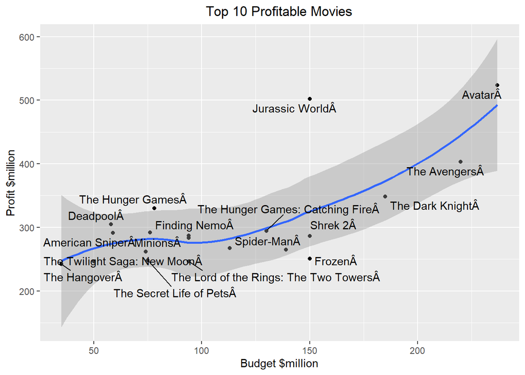

```r
IMDB = IMDB %>%
  mutate(profit = gross - budget,
         return_on_investment_perc = (profit/budget)*100)



#Top 20 movies based on its Profit
IMDB %>%
  filter(title_year %in% c(2000:2016)) %>%
  arrange(desc(profit)) %>%
  top_n(20, profit) %>%
  ggplot(aes(x=budget/1000000, y=profit/1000000)) +
  geom_point() +
  geom_smooth() +
  geom_text_repel(aes(label=movie_title)) +
  labs(x = "Budget $million", y = "Profit $million", title = "Top 10 Profitable Movies") +
  theme(plot.title = element_text(hjust = 0.5))
```

#### Genres

Our dataset was a bit “unclean”. Therefore, we have performed data pre-processing before our models. The first issue was the genres.

```r
head(IMDB$genres)
```

```
## [1] "Action|Adventure|Fantasy|Sci-Fi" "Action|Adventure|Fantasy"
## [3] "Action|Adventure|Thriller"       "Action|Thriller"
## [5] "Documentary"                     "Action|Adventure|Sci-Fi"
```

As seen above, most of the movies have more than one genres attributed to them and they are seperated by | sign. In order to make our analysis easier and since some movies have multiple genres attributed to them, we just keep the first genre that was given to the movie in the genre column, and create dummy variables for all movies genres, marking them as 1 if they belong to certain genre.

```r
genres = data.frame(do.call('rbind',strsplit(as.character(IMDB$genres),
                                                 '|',fixed=TRUE)))

all_genres <- unique(unlist(strsplit(as.character(IMDB$genres),'|',fixed=TRUE)))

dummy_genres = data.frame(matrix(ncol=length(all_genres),nrow=length(IMDB[,1])))
colnames(dummy_genres) <- all_genres

for (i in seq(length(IMDB[,1]))){
  dummy_genres[i, unique(unlist(genres[i,]))] = 1
}

dummy_genres[is.na(dummy_genres)] <-  0

#Check the sum of each genres
colSums(dummy_genres)
```

```
##      Action   Adventure     Fantasy      Sci-Fi    Thriller Documentary
##        1143         914         604         611        1396         121
##     Romance   Animation      Comedy      Family     Musical     Mystery
##        1098         242        1862         544         132         493
##     Western       Drama     History       Sport       Crime      Horror
##          94        2571         205         181         883         556
##         War   Biography       Music   Game-Show  Reality-TV        News
##         211         292         212           1           2           3
##       Short   Film-Noir
##           5           6
```

Since the last columns has so little number, we decide to drop them.

```r
dummy_genres <- dummy_genres[-c(22:26)]
head(dummy_genres)
```

|  | Action | Adventure | Fantasy | Sci-Fi | Thriller | Documentary | Romance | Animation | Comedy | Family | Musical | Mystery | Western | Drama | History | Sport | Crime | Horror | War | Biography | Music |
| --- | --- | --- | --- | --- | --- | --- | --- | --- | --- | --- | --- | --- | --- | --- | --- | --- | --- | --- | --- | --- | --- |
| 1 | 1 | 1 | 1 | 1 | 0 | 0 | 0 | 0 | 0 | 0 | 0 | 0 | 0 | 0 | 0 | 0 | 0 | 0 | 0 | 0 | 0 |
| 2 | 1 | 1 | 1 | 0 | 0 | 0 | 0 | 0 | 0 | 0 | 0 | 0 | 0 | 0 | 0 | 0 | 0 | 0 | 0 | 0 | 0 |
| 3 | 1 | 1 | 0 | 0 | 1 | 0 | 0 | 0 | 0 | 0 | 0 | 0 | 0 | 0 | 0 | 0 | 0 | 0 | 0 | 0 | 0 |
| 4 | 1 | 0 | 0 | 0 | 1 | 0 | 0 | 0 | 0 | 0 | 0 | 0 | 0 | 0 | 0 | 0 | 0 | 0 | 0 | 0 | 0 |
| 5 | 0 | 0 | 0 | 0 | 0 | 1 | 0 | 0 | 0 | 0 | 0 | 0 | 0 | 0 | 0 | 0 | 0 | 0 | 0 | 0 | 0 |
| 6 | 1 | 1 | 0 | 1 | 0 | 0 | 0 | 0 | 0 | 0 | 0 | 0 | 0 | 0 | 0 | 0 | 0 | 0 | 0 | 0 | 0 |

```r
IMDB = cbind(IMDB, dummy_genres)

IMDB$genres = genres$X1
head(IMDB)
```

|  | color | director_name | num_critic_for_reviews | duration | director_facebook_likes | actor_3_facebook_likes | actor_2_name | actor_1_facebook_likes | gross | genres | actor_1_name | movie_title | num_voted_users | cast_total_facebook_likes | actor_3_name | facenumber_in_poster | plot_keywords | movie_imdb_link | num_user_for_reviews | language | country | content_rating | budget | title_year | actor_2_facebook_likes | imdb_score | aspect_ratio | movie_facebook_likes | profit | … |
| --- | --- | --- | --- | --- | --- | --- | --- | --- | --- | --- | --- | --- | --- | --- | --- | --- | --- | --- | --- | --- | --- | --- | --- | --- | --- | --- | --- | --- | --- | --- |
| 1 | Color | James Cameron | 723 | 178 | 0 | 855 | Joel David Moore | 1000 | 760505847 | Action | CCH Pounder | AvatarÂ | 886204 | 4834 | Wes Studi | 0 | avatar\|future\|marine\|native\|paraplegic | http://www.imdb.com/title/tt0499549/?ref_=fn_tt_tt_1 | 3054 | English | USA | PG-13 | 237000000 | 2009 | 936 | 7.9 | 1.78 | 33000 | 523505847 | … |
| 2 | Color | Gore Verbinski | 302 | 169 | 563 | 1000 | Orlando Bloom | 40000 | 309404152 | Action | Johnny Depp | Pirates of the Caribbean: At World's EndÂ | 471220 | 48350 | Jack Davenport | 0 | goddess\|marriage ceremony\|marriage proposal\|pirate\|singapore | http://www.imdb.com/title/tt0449088/?ref_=fn_tt_tt_1 | 1238 | English | USA | PG-13 | 300000000 | 2007 | 5000 | 7.1 | 2.35 | 0 | 9404152 | … |
| 3 | Color | Sam Mendes | 602 | 148 | 0 | 161 | Rory Kinnear | 11000 | 200074175 | Action | Christoph Waltz | SpectreÂ | 275868 | 11700 | Stephanie Sigman | 1 | bomb\|espionage\|sequel\|spy\|terrorist | http://www.imdb.com/title/tt2379713/?ref_=fn_tt_tt_1 | 994 | English | UK | PG-13 | 245000000 | 2015 | 393 | 6.8 | 2.35 | 85000 | -44925825 | … |
| 4 | Color | Christopher Nolan | 813 | 164 | 22000 | 23000 | Christian Bale | 27000 | 448130642 | Action | Tom Hardy | The Dark Knight RisesÂ | 1144337 | 106759 | Joseph Gordon-Levitt | 0 | deception\|imprisonment\|lawlessness\|police officer\|terrorist plot | http://www.imdb.com/title/tt1345836/?ref_=fn_tt_tt_1 | 2701 | English | USA | PG-13 | 250000000 | 2012 | 23000 | 8.5 | 2.35 | 164000 | 198130642 | … |
| 5 |  | Doug Walker | NA | NA | 131 | NA | Rob Walker | 131 | NA | Documentary | Doug Walker | Star Wars: Episode VII - The Force AwakensÂ | 8 | 143 |  | 0 |  | http://www.imdb.com/title/tt5289954/?ref_=fn_tt_tt_1 | NA |  |  |  | NA | NA | 12 | 7.1 | NA | 0 | NA | … |
| 6 | Color | Andrew Stanton | 462 | 132 | 475 | 530 | Samantha Morton | 640 | 73058679 | Action | Daryl Sabara | John CarterÂ | 212204 | 1873 | Polly Walker | 1 | alien\|american civil war\|male nipple\|mars\|princess | http://www.imdb.com/title/tt0401729/?ref_=fn_tt_tt_1 | 738 | English | USA | PG-13 | 263700000 | 2012 | 632 | 6.6 | 2.35 | 24000 | -190641321 | … |

### C. Visaulization Analysis

Later, we have performed visual analysis in order to understand the data and the patterns in the data. Another reason we have performed visual analysis was to understand if there are any outliers and dominant variables that we might need to adress in future.

```r
#Overview on Categorical and Continuous variables
cat_plot<-function(data,var){ ggplot(IMDB,aes(x=var,y=imdb_score,alpha=0.5,col=var))+
labs(title=colnames(as.data.frame( data$var)))+
geom_jitter() }

cont_plot<-function(data,var){ ggplot(IMDB,aes(x=var,y=imdb_score,alpha=0.1))+
labs(title=paste("", names(var)))+
geom_point() }
```

#### Some Continuous Variables

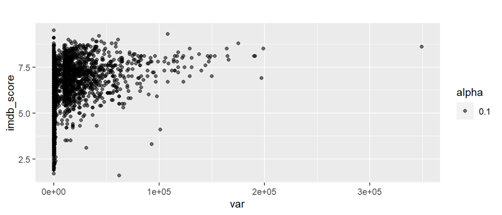

```r
#Some of the continuous variables
cont_plot(IMDB, IMDB$movie_facebook_likes)
```

We can see that there is slightly a positive relationship between Facebook movie likes and IMDB score although it is not very obvious.

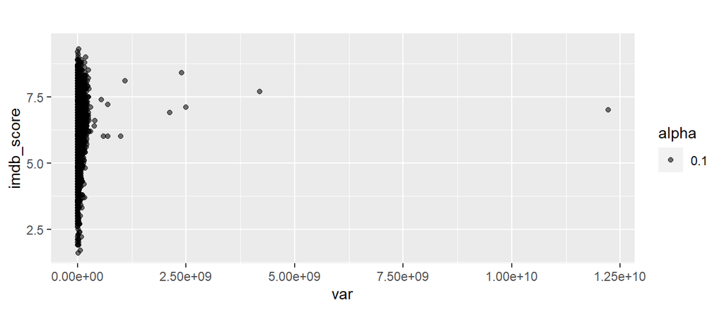

```r
cont_plot(IMDB, IMDB$budget)
```

We do not observe a particular pattern between IMDB score and budget of the movie.

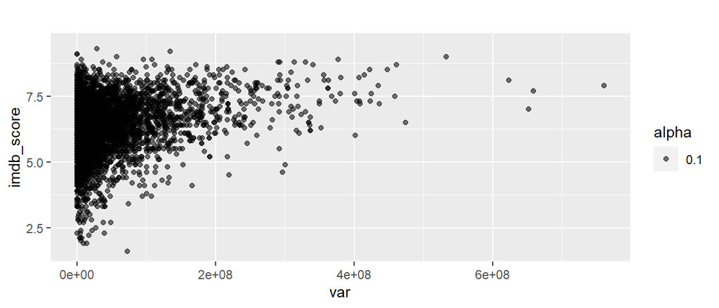

```r
cont_plot(IMDB, IMDB$gross)
```

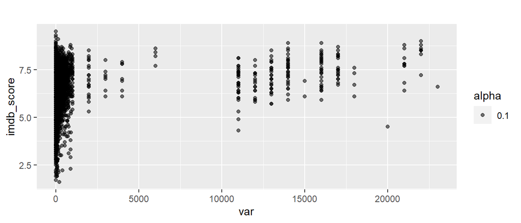

```r
cont_plot(IMDB, IMDB$director_facebook_likes)
```

Although movies that have its director’s Facebook likes high have high IMDB scores generally, we cannot not say that there is a positive relationship between IMDB score and facebook director likes particularly as directors that have low facebook likes can have high imdb scores as seen from the plot. This might be because the Director doesn’t have a page on Facebook but still a well known director.

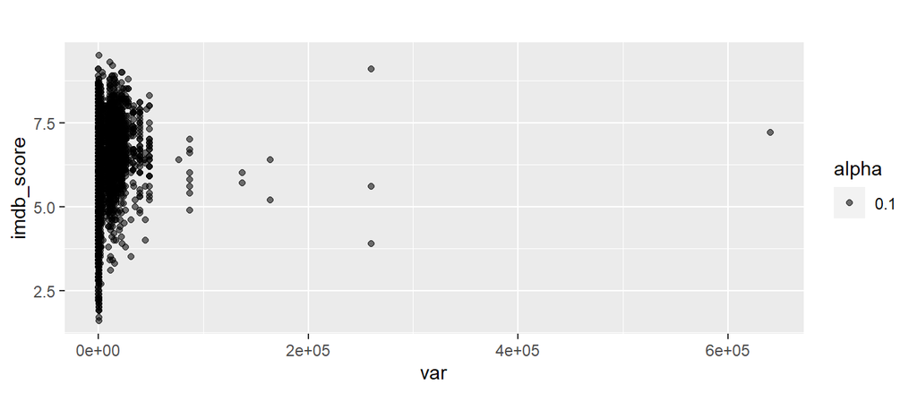

```r
cont_plot(IMDB, IMDB$actor_1_facebook_likes)
```

We do not observe a particular pattern between IMDB score and Facebook likes of actor 1 of the movie.

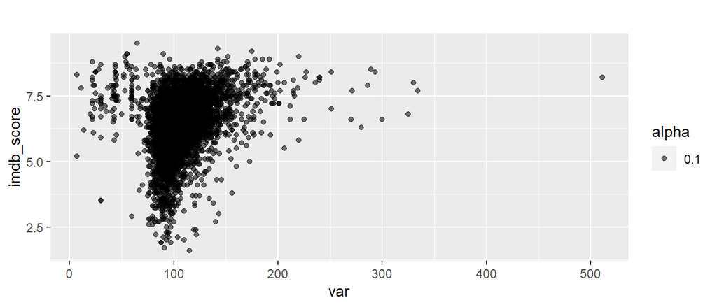

```r
cont_plot(IMDB, IMDB$duration)
```

We do not observe a particular pattern between IMDB score and duration of the movie.

#### Some Categorical Variables

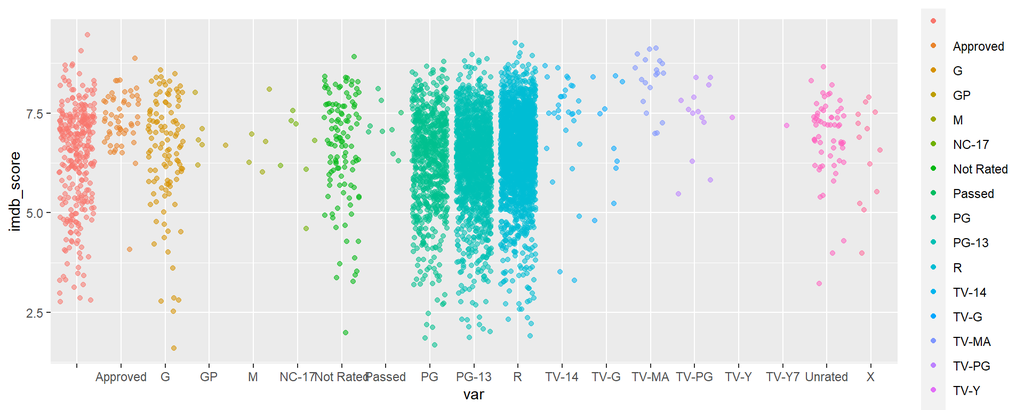

```r
cat_plot(IMDB, IMDB$content_rating )
```

We can see that most of the movies in our dataset has content rating of PG, PG-13 and R.

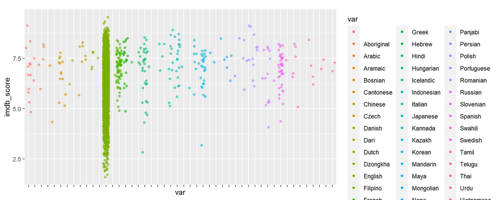

```r
cat_plot(IMDB, IMDB$language )+ scale_x_discrete(labels = NULL)
```

As seen from the plot, English is the dominating language of the movies. Although there are other movies with different languages, they are very few.

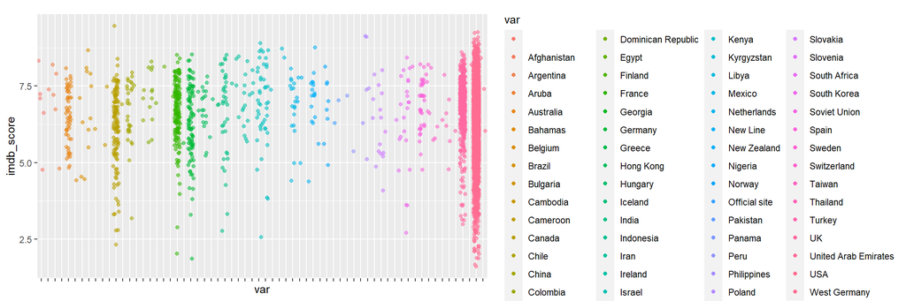

```r
cat_plot(IMDB, IMDB$country )+ scale_x_discrete(labels = NULL)
```

The plot shows that USA is the dominant country for the movies. But unlike what we have seen in the languages, other countries do not look like outliers as they good amount of movies as well.

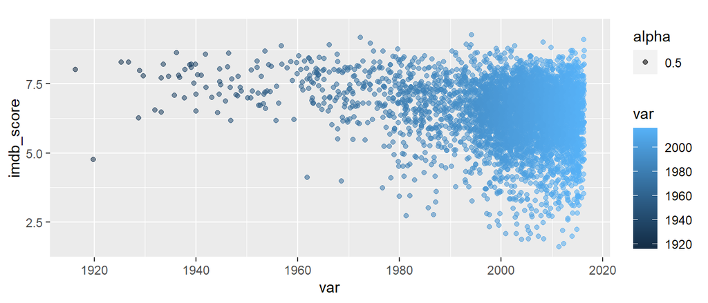

```r
cat_plot(IMDB, IMDB$title_year )
```

The plot shows that the dataset doesn’t have many movies that were filmed before 1980. Thus we might think the movies before 1980s as outliers later when we are rearranging our data.

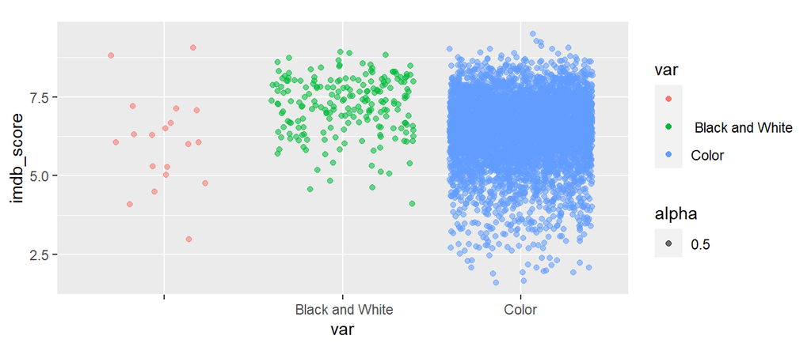

```r
cat_plot(IMDB, IMDB$color )
```

Colored movies are dominant in the data.

### D. Removing useless variables

To decide which variables keep in our data and which variables are important, we have looked at two different aspects.

```r
# Check total number of unique value for the variables selected
sum(uniqueN(IMDB$director_name))
```

```
## [1] 2399
```

```r
sum(uniqueN(IMDB[, c("actor_1_name", "actor_2_name", "actor_3_name")]))
```

```
## [1] 4884
```

```r
sum(uniqueN(IMDB$movie_imdb_link))
```

```
## [1] 4919
```

```r
sum(uniqueN(IMDB$movie_title))
```

```
## [1] 4917
```

```r
sum(uniqueN(IMDB$plot_keywords))
```

```
## [1] 4761
```

Below variables have values that dominating almost all of the observations. Thus, we believed that keeping them would not be useful.

```r
table(IMDB$aspect_ratio)
```

```
##
## 1.18  1.2 1.33 1.37 1.44  1.5 1.66 1.75 1.77 1.78 1.85 1.89    2  2.2 2.24 2.35
##    1    1   67  100    1    2   64    3    1  108 1890    1    5   14    1 2337
## 2.39  2.4 2.55 2.76    4   16
##   15    3    2    3    7   45
```

```r
table(IMDB$color)
```

```
##
##                   Black and White            Color
##               19              207             4772
```

```r
table(IMDB$language)
```

```
##
##            Aboriginal     Arabic    Aramaic    Bosnian  Cantonese    Chinese
##         12          2          5          1          1         11          3
##      Czech     Danish       Dari      Dutch   Dzongkha    English   Filipino
##          1          5          2          4          1       4662          1
##     French     German      Greek     Hebrew      Hindi  Hungarian  Icelandic
##         73         19          1          5         28          1          2
## Indonesian    Italian   Japanese    Kannada     Kazakh     Korean   Mandarin
##          2         11         17          1          1          8         24
##       Maya  Mongolian       None  Norwegian    Panjabi    Persian     Polish
##          1          1          2          4          1          4          4
## Portuguese   Romanian    Russian  Slovenian    Spanish    Swahili    Swedish
##          8          2         11          1         40          1          5
##      Tamil     Telugu       Thai       Urdu Vietnamese       Zulu
##          1          1          3          1          1          2
```

```r
table(IMDB$country)
```

```
##
##                               Afghanistan            Argentina
##                    5                    1                    4
##                Aruba            Australia              Bahamas
##                    1                   55                    1
##              Belgium               Brazil             Bulgaria
##                    4                    8                    1
##             Cambodia             Cameroon               Canada
##                    1                    1                  124
##                Chile                China             Colombia
##                    1                   28                    1
##       Czech Republic              Denmark   Dominican Republic
##                    3                   11                    1
##                Egypt              Finland               France
##                    1                    1                  154
##              Georgia              Germany               Greece
##                    1                   96                    2
##            Hong Kong              Hungary              Iceland
##                   17                    2                    3
##                India            Indonesia                 Iran
##                   34                    1                    4
##              Ireland               Israel                Italy
##                   12                    4                   23
##                Japan                Kenya           Kyrgyzstan
##                   22                    1                    1
##                Libya               Mexico          Netherlands
##                    1                   17                    5
##             New Line          New Zealand              Nigeria
##                    1                   15                    1
##               Norway        Official site             Pakistan
##                    8                    1                    1
##               Panama                 Peru          Philippines
##                    1                    1                    1
##               Poland              Romania               Russia
##                    5                    4                   11
##             Slovakia             Slovenia         South Africa
##                    1                    1                    8
##          South Korea         Soviet Union                Spain
##                   14                    1                   33
##               Sweden          Switzerland               Taiwan
##                    6                    3                    2
##             Thailand               Turkey                   UK
##                    5                    1                  443
## United Arab Emirates                  USA         West Germany
##                    1                 3773                    3
```

```r
levels(IMDB$country) = c(levels(IMDB$country), "Others")
IMDB$country[(IMDB$country != 'USA')] <- 'Others'
IMDB$country <- factor(IMDB$country)
table(IMDB$country)
```

```
##
## Others    USA
##   1225   3773
```

```r
# Removing useless variables

#since movies later than 1980 dominant, we only keep those
IMDB = IMDB[IMDB$title_year >= 1980,]

#deleting very diversified variables
IMDB = subset(IMDB, select = -c(aspect_ratio,color,language,
                                director_name,actor_1_name,
                                actor_2_name, actor_3_name, content_rating,
                                movie_title,  plot_keywords, movie_imdb_link,
                                return_on_investment_perc, profit))

head(IMDB)
```

|  | num_critic_for_reviews | duration | director_facebook_likes | actor_3_facebook_likes | actor_1_facebook_likes | gross | genres | num_voted_users | cast_total_facebook_likes | facenumber_in_poster | num_user_for_reviews | country | budget | title_year | actor_2_facebook_likes | imdb_score | movie_facebook_likes | Action | Adventure | Fantasy | Sci-Fi | Thriller | Documentary | Romance | Animation | Comedy | Family | Musical | Mystery | … |
| --- | --- | --- | --- | --- | --- | --- | --- | --- | --- | --- | --- | --- | --- | --- | --- | --- | --- | --- | --- | --- | --- | --- | --- | --- | --- | --- | --- | --- | --- | --- |
| 1 | 723 | 178 | 0 | 855 | 1000 | 760505847 | Action | 886204 | 4834 | 0 | 3054 | USA | 237000000 | 2009 | 936 | 7.9 | 33000 | 1 | 1 | 1 | 1 | 0 | 0 | 0 | 0 | 0 | 0 | 0 | 0 | … |
| 2 | 302 | 169 | 563 | 1000 | 40000 | 309404152 | Action | 471220 | 48350 | 0 | 1238 | USA | 300000000 | 2007 | 5000 | 7.1 | 0 | 1 | 1 | 1 | 0 | 0 | 0 | 0 | 0 | 0 | 0 | 0 | 0 | … |
| 3 | 602 | 148 | 0 | 161 | 11000 | 200074175 | Action | 275868 | 11700 | 1 | 994 | Others | 245000000 | 2015 | 393 | 6.8 | 85000 | 1 | 1 | 0 | 0 | 1 | 0 | 0 | 0 | 0 | 0 | 0 | 0 | … |
| 4 | 813 | 164 | 22000 | 23000 | 27000 | 448130642 | Action | 1144337 | 106759 | 0 | 2701 | USA | 250000000 | 2012 | 23000 | 8.5 | 164000 | 1 | 0 | 0 | 0 | 1 | 0 | 0 | 0 | 0 | 0 | 0 | 0 | … |
| NA | NA | NA | NA | NA | NA | NA | NA | NA | NA | NA | NA | NA | NA | NA | NA | NA | NA | NA | NA | NA | NA | NA | NA | NA | NA | NA | NA | NA | NA | … |
| 6 | 462 | 132 | 475 | 530 | 640 | 73058679 | Action | 212204 | 1873 | 1 | 738 | USA | 263700000 | 2012 | 632 | 6.6 | 24000 | 1 | 1 | 0 | 1 | 0 | 0 | 0 | 0 | 0 | 0 | 0 | 0 | … |

### E. Missing Values

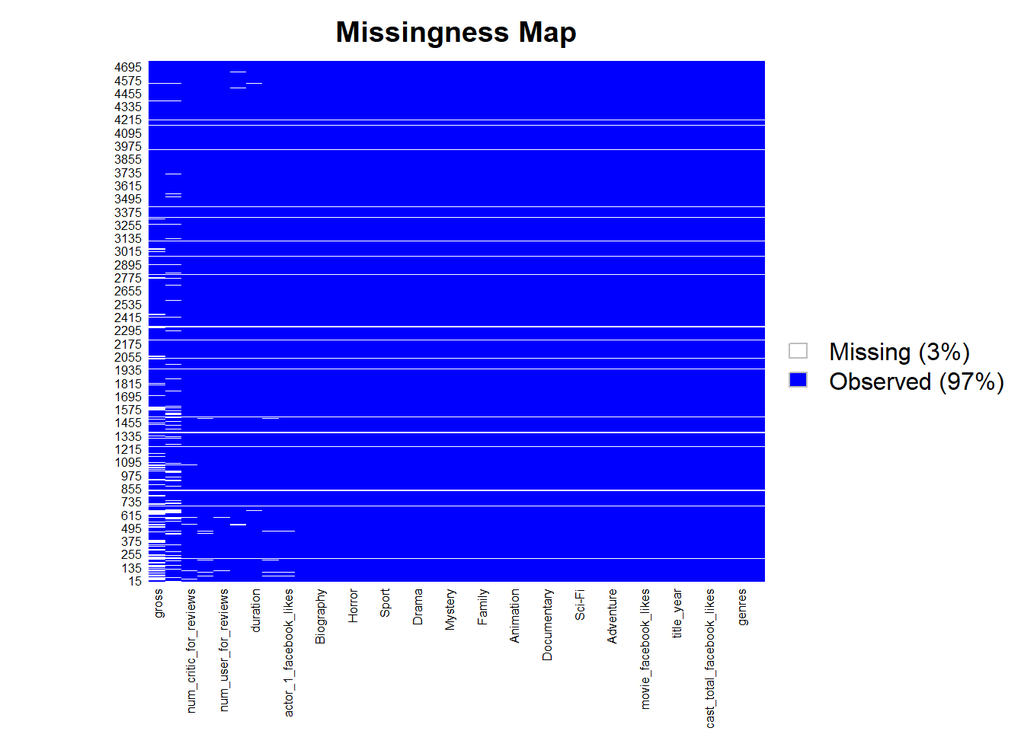

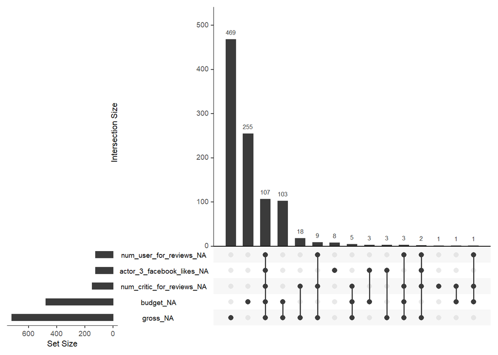

```r
#Looking at the data to see if we have any missing variables
missmap(IMDB[, ], col = c("white", "blue"),
        y.cex = 0.5, x.cex = 0.5, rank.order = TRUE)
gg_miss_upset(IMDB)
```

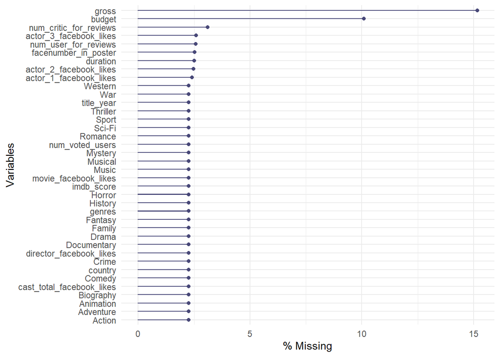

```r
gg_miss_var(IMDB, show_pct = TRUE)
```

```r
colSums(sapply(IMDB, is.na))
```

```
##    num_critic_for_reviews                  duration   director_facebook_likes
##                       147                       119                       107
##    actor_3_facebook_likes    actor_1_facebook_likes                     gross
##                       123                       114                       719
##                    genres           num_voted_users cast_total_facebook_likes
##                       107                       107                       107
##      facenumber_in_poster      num_user_for_reviews                   country
##                       120                       122                       107
##                    budget                title_year    actor_2_facebook_likes
##                       478                       107                       117
##                imdb_score      movie_facebook_likes                    Action
##                       107                       107                       107
##                 Adventure                   Fantasy                    Sci-Fi
##                       107                       107                       107
##                  Thriller               Documentary                   Romance
##                       107                       107                       107
##                 Animation                    Comedy                    Family
##                       107                       107                       107
##                   Musical                   Mystery                   Western
##                       107                       107                       107
##                     Drama                   History                     Sport
##                       107                       107                       107
##                     Crime                    Horror                       War
##                       107                       107                       107
##                 Biography                     Music
##                       107                       107
```

```r
#dropping rows with the missing values in genres
IMDB = IMDB[complete.cases(IMDB[19:38]),]
colSums(sapply(IMDB, is.na))
```

```
##    num_critic_for_reviews                  duration   director_facebook_likes
##                        40                        12                         0
##    actor_3_facebook_likes    actor_1_facebook_likes                     gross
##                        16                         7                       612
##                    genres           num_voted_users cast_total_facebook_likes
##                         0                         0                         0
##      facenumber_in_poster      num_user_for_reviews                   country
##                        13                        15                         0
##                    budget                title_year    actor_2_facebook_likes
##                       371                         0                        10
##                imdb_score      movie_facebook_likes                    Action
##                         0                         0                         0
##                 Adventure                   Fantasy                    Sci-Fi
##                         0                         0                         0
##                  Thriller               Documentary                   Romance
##                         0                         0                         0
##                 Animation                    Comedy                    Family
##                         0                         0                         0
##                   Musical                   Mystery                   Western
##                         0                         0                         0
##                     Drama                   History                     Sport
##                         0                         0                         0
##                     Crime                    Horror                       War
##                         0                         0                         0
##                 Biography                     Music
##                         0                         0
```

Now let’s deal with the rest NA.

```r
#handling missing values-- Replacing with column means

IMDB$num_critic_for_reviews[is.na(IMDB$num_critic_for_reviews)] = round(
  mean(IMDB$num_critic_for_reviews, na.rm = TRUE))

IMDB$budget[is.na(IMDB$budget)] = round(mean(IMDB$budget, na.rm = TRUE))

IMDB$gross[is.na(IMDB$gross)] = round(median(IMDB$gross, na.rm = TRUE))

#Drop the rest NA

#checking if there are any N/A values left
IMDB = IMDB[complete.cases(IMDB),]
colSums(sapply(IMDB, is.na))
```

```
##    num_critic_for_reviews                  duration   director_facebook_likes
##                         0                         0                         0
##    actor_3_facebook_likes    actor_1_facebook_likes                     gross
##                         0                         0                         0
##                    genres           num_voted_users cast_total_facebook_likes
##                         0                         0                         0
##      facenumber_in_poster      num_user_for_reviews                   country
##                         0                         0                         0
##                    budget                title_year    actor_2_facebook_likes
##                         0                         0                         0
##                imdb_score      movie_facebook_likes                    Action
##                         0                         0                         0
##                 Adventure                   Fantasy                    Sci-Fi
##                         0                         0                         0
##                  Thriller               Documentary                   Romance
##                         0                         0                         0
##                 Animation                    Comedy                    Family
##                         0                         0                         0
##                   Musical                   Mystery                   Western
##                         0                         0                         0
##                     Drama                   History                     Sport
##                         0                         0                         0
##                     Crime                    Horror                       War
##                         0                         0                         0
##                 Biography                     Music
##                         0                         0
```

```r
head(IMDB)
```

|  | num_critic_for_reviews | duration | director_facebook_likes | actor_3_facebook_likes | actor_1_facebook_likes | gross | genres | num_voted_users | cast_total_facebook_likes | facenumber_in_poster | num_user_for_reviews | country | budget | title_year | actor_2_facebook_likes | imdb_score | movie_facebook_likes | Action | Adventure | Fantasy | Sci-Fi | Thriller | Documentary | Romance | Animation | Comedy | Family | Musical | Mystery | … |
| --- | --- | --- | --- | --- | --- | --- | --- | --- | --- | --- | --- | --- | --- | --- | --- | --- | --- | --- | --- | --- | --- | --- | --- | --- | --- | --- | --- | --- | --- | --- |
| 1 | 723 | 178 | 0 | 855 | 1000 | 760505847 | Action | 886204 | 4834 | 0 | 3054 | USA | 237000000 | 2009 | 936 | 7.9 | 33000 | 1 | 1 | 1 | 1 | 0 | 0 | 0 | 0 | 0 | 0 | 0 | 0 | … |
| 2 | 302 | 169 | 563 | 1000 | 40000 | 309404152 | Action | 471220 | 48350 | 0 | 1238 | USA | 300000000 | 2007 | 5000 | 7.1 | 0 | 1 | 1 | 1 | 0 | 0 | 0 | 0 | 0 | 0 | 0 | 0 | 0 | … |
| 3 | 602 | 148 | 0 | 161 | 11000 | 200074175 | Action | 275868 | 11700 | 1 | 994 | Others | 245000000 | 2015 | 393 | 6.8 | 85000 | 1 | 1 | 0 | 0 | 1 | 0 | 0 | 0 | 0 | 0 | 0 | 0 | … |
| 4 | 813 | 164 | 22000 | 23000 | 27000 | 448130642 | Action | 1144337 | 106759 | 0 | 2701 | USA | 250000000 | 2012 | 23000 | 8.5 | 164000 | 1 | 0 | 0 | 0 | 1 | 0 | 0 | 0 | 0 | 0 | 0 | 0 | … |
| 6 | 462 | 132 | 475 | 530 | 640 | 73058679 | Action | 212204 | 1873 | 1 | 738 | USA | 263700000 | 2012 | 632 | 6.6 | 24000 | 1 | 1 | 0 | 1 | 0 | 0 | 0 | 0 | 0 | 0 | 0 | 0 | … |
| 7 | 392 | 156 | 0 | 4000 | 24000 | 336530303 | Action | 383056 | 46055 | 0 | 1902 | USA | 258000000 | 2007 | 11000 | 6.2 | 0 | 1 | 1 | 0 | 0 | 0 | 0 | 1 | 0 | 0 | 0 | 0 | 0 | … |

### F. Correlation Plot

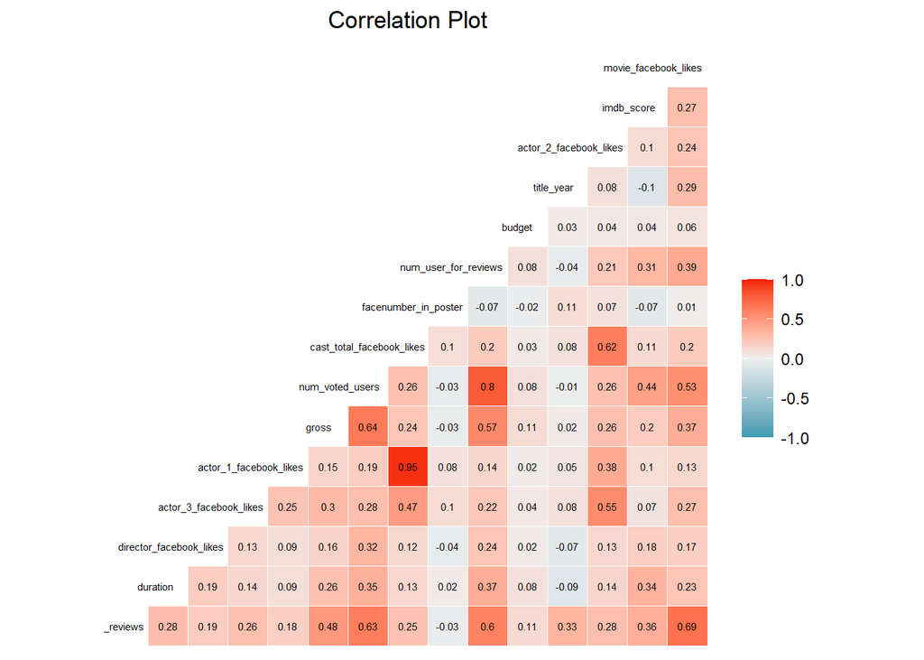

```r
#Correlation Map
ggcorr(IMDB[1:17], label = TRUE, label_round = 2,
       label_size = 2, size = 2, hjust = .85) +
  ggtitle("Correlation Plot") +
  theme(plot.title = element_text(hjust = 0.5))
```

### G. Data Visualization

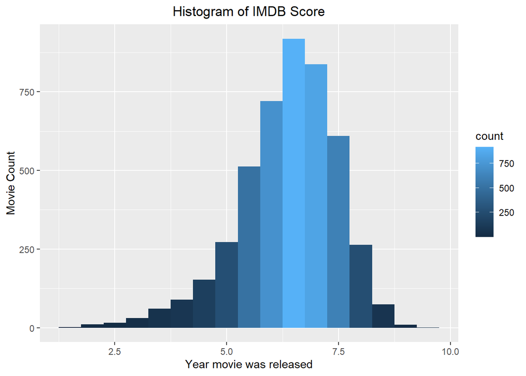

```r
#Histogram of IMDB Score
ggplot(IMDB, aes(imdb_score)) +
  geom_histogram(aes(fill = ..count..), binwidth =0.5) +
  labs(x = "Year movie was released", y = "Movie Count", title = "Histogram of IMDB Score") +
  theme(plot.title = element_text(hjust = 0.5))
```

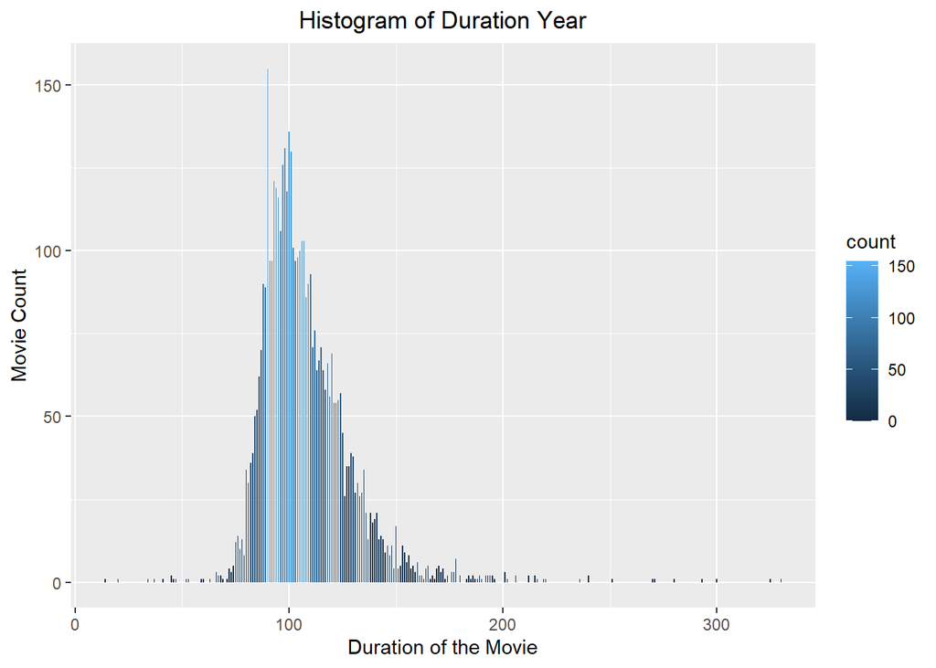

```r
#Histogram of Duration
ggplot(IMDB, aes(duration)) +
  geom_histogram(aes(fill = ..count..), binwidth =0.5) +
  labs(x = "Duration of the Movie", y = "Movie Count", title = "Histogram of Duration Year") +
  theme(plot.title = element_text(hjust = 0.5))
```

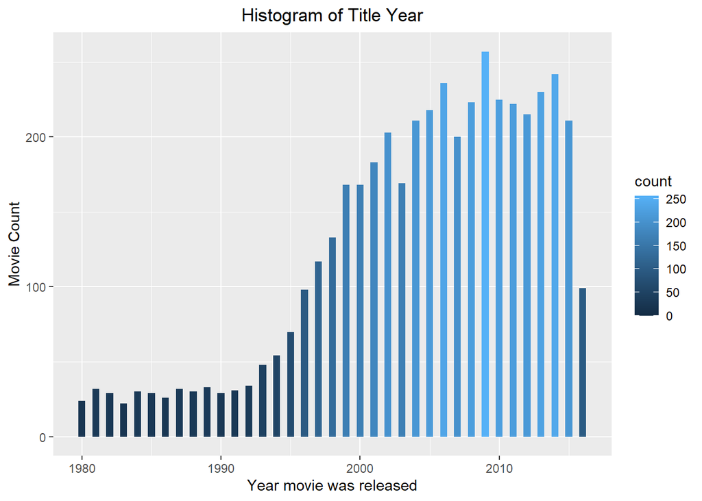

```r
#Histogram of Title Year
ggplot(IMDB, aes(title_year)) +
  geom_histogram(aes(fill = ..count..), binwidth =0.5) +
  labs(x = "Year movie was released", y = "Movie Count", title = "Histogram of Title Year") +
  theme(plot.title = element_text(hjust = 0.5))
```

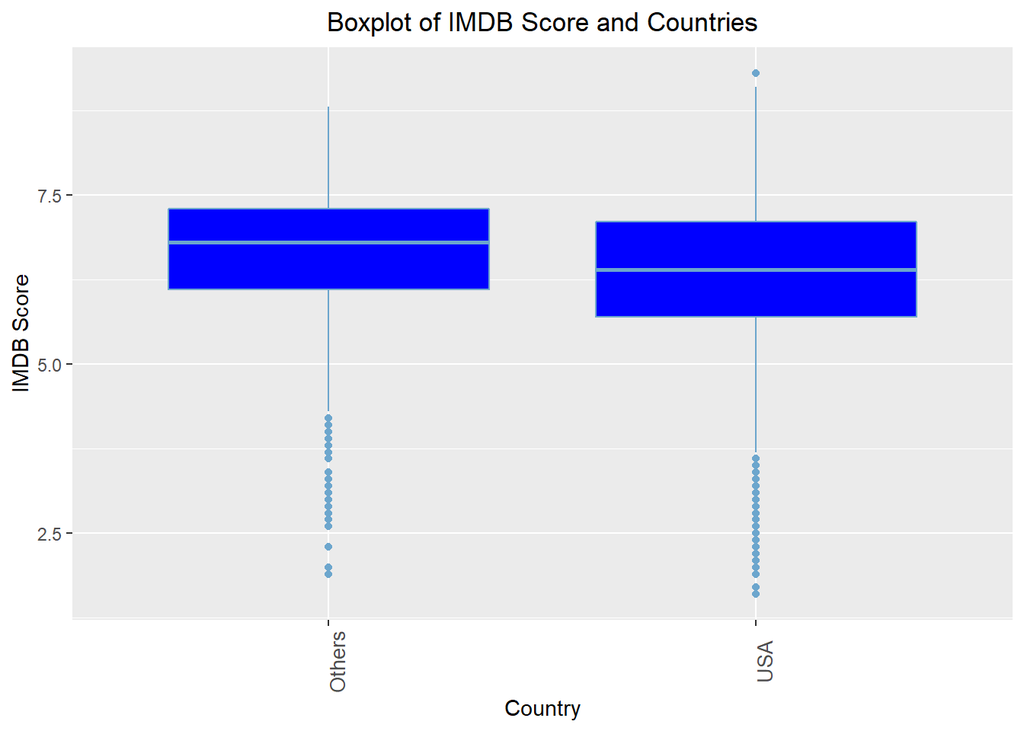

```r
#Boxplot
ggplot(IMDB, aes(x = country, y = imdb_score)) +
        geom_boxplot(fill = "Blue", colour = "skyblue3") +
        scale_y_continuous(name = "IMDB Score") +
        scale_x_discrete(name = "Country") +
        ggtitle("Boxplot of IMDB Score and Countries") +
        theme(plot.title = element_text(hjust = 0.5),
                           axis.text.x  = element_text(angle = 90,
                           size = 10))
```

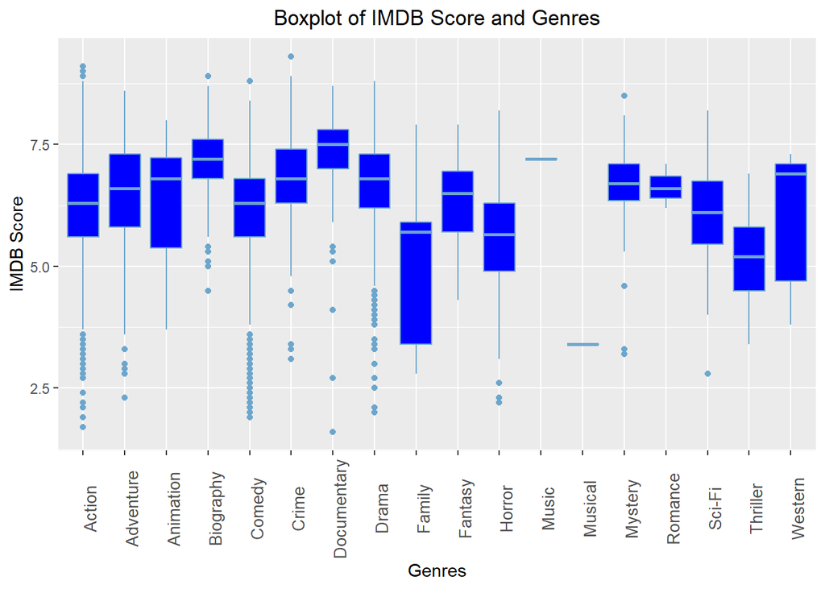

```r
#Boxplot
ggplot(IMDB, aes(x = genres, y = imdb_score)) +
        geom_boxplot(fill = "Blue", colour = "skyblue3") +
        scale_y_continuous(name = "IMDB Score") +
        scale_x_discrete(name = "Genres") +
        ggtitle("Boxplot of IMDB Score and Genres") +
        theme(plot.title = element_text(hjust = 0.5),
                           axis.text.x  = element_text(angle = 90,
                           size = 10))
```

## III. Model Fitting: Regularization

Regularization is used to improve linear regression by introducing a penalty term to the cost function and by replacing the least square fitting with some alternative fitting procedure, through minimizing the mean square error (MSE).

For variable selection process, we could have used subset selection methods such as stepwise regression. The disadvantage of stepwise regression is that in can be a bit biased and it gets worse when there are a lot of variables. An alternative is to use some of the shrinkage methods such as Ridge, Lasso and Elastic Net. Shrinkage method is used to increase accuracy and still have interpretability. In the first part of our models, we will use the shrinkage methods.

In our dataset, we have the country and the genres variables as categorical. Thus, we have changed them into dummy variables in order to make analysis easier.

```r
# Genres
IMDB = subset(IMDB, select = -genres)

head(IMDB)
```

|  | num_critic_for_reviews | duration | director_facebook_likes | actor_3_facebook_likes | actor_1_facebook_likes | gross | num_voted_users | cast_total_facebook_likes | facenumber_in_poster | num_user_for_reviews | country | budget | title_year | actor_2_facebook_likes | imdb_score | movie_facebook_likes | Action | Adventure | Fantasy | Sci-Fi | Thriller | Documentary | Romance | Animation | Comedy | Family | Musical | Mystery | Western | … |
| --- | --- | --- | --- | --- | --- | --- | --- | --- | --- | --- | --- | --- | --- | --- | --- | --- | --- | --- | --- | --- | --- | --- | --- | --- | --- | --- | --- | --- | --- | --- |
| 1 | 723 | 178 | 0 | 855 | 1000 | 760505847 | 886204 | 4834 | 0 | 3054 | USA | 237000000 | 2009 | 936 | 7.9 | 33000 | 1 | 1 | 1 | 1 | 0 | 0 | 0 | 0 | 0 | 0 | 0 | 0 | 0 | … |
| 2 | 302 | 169 | 563 | 1000 | 40000 | 309404152 | 471220 | 48350 | 0 | 1238 | USA | 300000000 | 2007 | 5000 | 7.1 | 0 | 1 | 1 | 1 | 0 | 0 | 0 | 0 | 0 | 0 | 0 | 0 | 0 | 0 | … |
| 3 | 602 | 148 | 0 | 161 | 11000 | 200074175 | 275868 | 11700 | 1 | 994 | Others | 245000000 | 2015 | 393 | 6.8 | 85000 | 1 | 1 | 0 | 0 | 1 | 0 | 0 | 0 | 0 | 0 | 0 | 0 | 0 | … |
| 4 | 813 | 164 | 22000 | 23000 | 27000 | 448130642 | 1144337 | 106759 | 0 | 2701 | USA | 250000000 | 2012 | 23000 | 8.5 | 164000 | 1 | 0 | 0 | 0 | 1 | 0 | 0 | 0 | 0 | 0 | 0 | 0 | 0 | … |
| 6 | 462 | 132 | 475 | 530 | 640 | 73058679 | 212204 | 1873 | 1 | 738 | USA | 263700000 | 2012 | 632 | 6.6 | 24000 | 1 | 1 | 0 | 1 | 0 | 0 | 0 | 0 | 0 | 0 | 0 | 0 | 0 | … |
| 7 | 392 | 156 | 0 | 4000 | 24000 | 336530303 | 383056 | 46055 | 0 | 1902 | USA | 258000000 | 2007 | 11000 | 6.2 | 0 | 1 | 1 | 0 | 0 | 0 | 0 | 1 | 0 | 0 | 0 | 0 | 0 | 0 | … |

#### Partioning Data

```r
#Splitting the data
set.seed(412)
train = sample.split(IMDB$imdb_score, SplitRatio = 0.75)

IMDB_train <- subset(IMDB, train == TRUE)
IMDB_test <- subset(IMDB, train == FALSE)
```

We have randomly split our data to create our training and testing sets. Training data consists of 75 percent of the whole data and testing data consists of 25 percent of the whole data.

```r
#Train and Test Data x and Y variables
#predictor variables
X_train = model.matrix(imdb_score ~ ., IMDB_train )[, -1]
#outcome variables
y_train = IMDB_train$imdb_score

X_test = model.matrix(imdb_score ~ ., IMDB_test)[, -1]
y_test = IMDB_test$imdb_score
```

#### Shrinkage - Ridge, Lasso, Elastic Net

– Involves shrinking the estimated coefficients towards zero – This shrinkage reduces the variance

### A. Ridge

Ridge regression works well when there is multicollinearity. Ridge regression is used for independent variables with multicolinearity. When multicollinearity occurs, least squares estimates are unbiased, but their variances are large so they may be far from the true value. By adding a degree of bias to the regression estimates, ridge regression reduces the standard errors.

• In general, the ridge regression estimates will be more biased than the OLS ones but have lower variance • Ridge regression will work best in situations where the OLS estimates have high variance (when number of observations and predictors are close) • Ridge Regression can even be used when p > n, a situation where OLS fails completely!

alpha = 0 is ridge, alpha = 1 is lasso

Ridge regression minimizes squared error while regularizing the norm of the weights:
$$Ridge = RSS + \lambda\sum_{j=1} (\beta_j^2)$$
where $\lambda\sum_{j=1} (\beta_j^2)$ is the penalty term and $\lambda$ is tuning (shrinkage) parameter. $\beta_{ridge}$ chosen to minimize the penalized sum of squares. As shrinkage variable ($\lambda$) increases coefficients shrinks towards zero, increases bias but decreases variance. If lambda is large in loss function, it will lead to under-fitting problem. This model works well on avoiding over-fitting.

#### Fitting Ridge Model and Selecting lambda using 5-fold cross-validation

We would like to choose lambda that reduces the mean squared error (which introduces the smallest bias) and get the value that is the minimum in the cross validation plot. This process uses 5-fold cross validation to find the best lambda by selecting the lambda with the smallest mean cross-validated error.

Standarize = true makes standarization for predictors:

First we have used cross validation in order to choose the optimal $\lambda$ that minimizes the mean squared error.

```r
# Perform 10-fold cross-validation to select lambda ---------------------------
lambdas_to_try <- 10^seq(-3, 3, length.out = 100)

# Setting alpha = 0 implements ridge regression
set.seed(412)
ridge_model = cv.glmnet(X_train, y_train,
                     alpha = 0, lambda = lambdas_to_try,
                      standardize = TRUE, nfolds = 5)
```

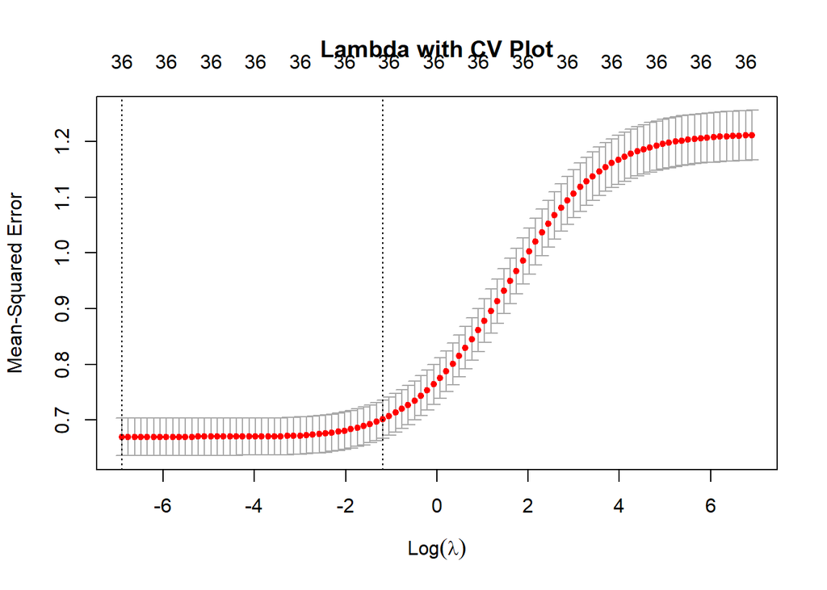

```r
# Plot cross-validation results
plot(ridge_model, main = "Lambda with CV Plot")
```

This figure shows cross-validation results for different $log\lambda$s.

```r
# Best cross-validated lambda
lambda_ridge = ridge_model$lambda.min
lambda_ridge
```

```
## [1] 0.001
```

The cross-validation results and the regression results tells us that the optimal $\lambda$ by mean squared error is 0.001.

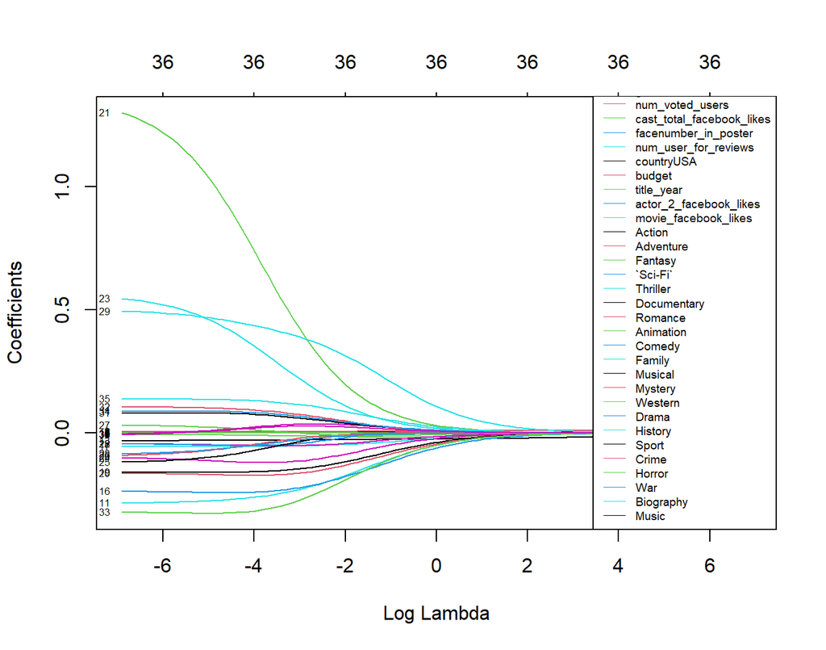

```r
# See how increasing lambda shrinks the coefficients --------------------------
# Each line shows coefficients for one variables, for different lambdas.
# The higher the lambda, the more the coefficients are shrinked towards zero.

res <- glmnet(X_train, y_train, alpha = 0, lambda = lambdas_to_try, standardize = FALSE)
plot(res, xvar = "lambda",label=TRUE)
legend("bottomright", lwd = 0.8, col = 1:5, legend = colnames(X_train), cex = .6)
```

The plot has $log(\lambda)$ on x-axis and the coefficients of the predictor variables on the y-axis. We observe that coefficeints of the predictors decay to zero as $log(\lambda)$ increases.

#### Testing on testing sample

For this part, we train the ridge regression on our training sample first using the optimal $\lambda$ that we have found above.

```r
# Fit final model, get its sum of squared residuals and multiple R-squared

ridge_fit  <- glmnet(X_train, y_train, alpha = 0, lambda = lambda_ridge, standardize = TRUE)
y_hat_ridge <- predict(ridge_fit ,  X_test)

ssr_ridge =  t(y_test - y_hat_ridge) %*% (y_test - y_hat_ridge)
rsq_ridge =  cor(y_test, y_hat_ridge)^2

sst <- sum((y_test - mean(y_test))^2)
sse_ridge <- sum((y_hat_ridge  - y_test)^2)
R2_ridge <- 1 - sse_ridge / sst

# Evaluate performance and save it
performance <- data.frame(Ridge=postResample(pred = y_hat_ridge, obs = y_test))
performance
```

|  | Ridge |
| --- | --- |
| RMSE | 0.8020885 |
| Rsquared | 0.4627025 |
| MAE | 0.5868651 |

We found that the Ridge Regression that was trained on training sample gives an $R^2$ value of 0.4627 on the testing sample. The $R^2$ is not very good. Thus, we will fit other models to understand if we can increase the performance.

### B. LASSO

One significant problem with Ridge is that the penalty term will never force any of the coefficients to be exactly zero. The LASSO, Least Absolute Shrinkage and Selection Operator, works in a similar way to Ridge Regression, except it uses a different penalty term. With LASSO, we can produce a model that has high predictive power and it is simple to interpret. Lasso is an advanced version of Linear Regression, it adds a penalty term (absolute value of magnitude) to loss function. Shrinking and removing less important feature’s coefficients can reduce variance without increasing bias. Lasso can raise the accuracy and reduce over-fitting.

Lasso regression minimizes squared error while regularizing the norm of the weights:
$$Lasso = RSS + \lambda\sum_{j=1} (|\beta_j|)$$
where $\lambda\sum_{j=1} (|\beta_j|)$ is the penalty term and $\lambda$ is tuning (shrinkage) parameter.

#### Fitting Lasso Model and Selecting lambda using 5-fold cross-validation

We used cross-validation to estimate the error rate for each value of $\lambda$ and select the value that gives the least error rate.

```r
# Setting alpha = 1 implements Lasso regression
lambdas_to_try <- 10^seq(-3, 3, length.out = 100)

set.seed(412)
lasso_model = cv.glmnet(X_train, y_train,
                     alpha = 1, lambda = lambdas_to_try,
                      standardize = TRUE, nfolds = 5)
```

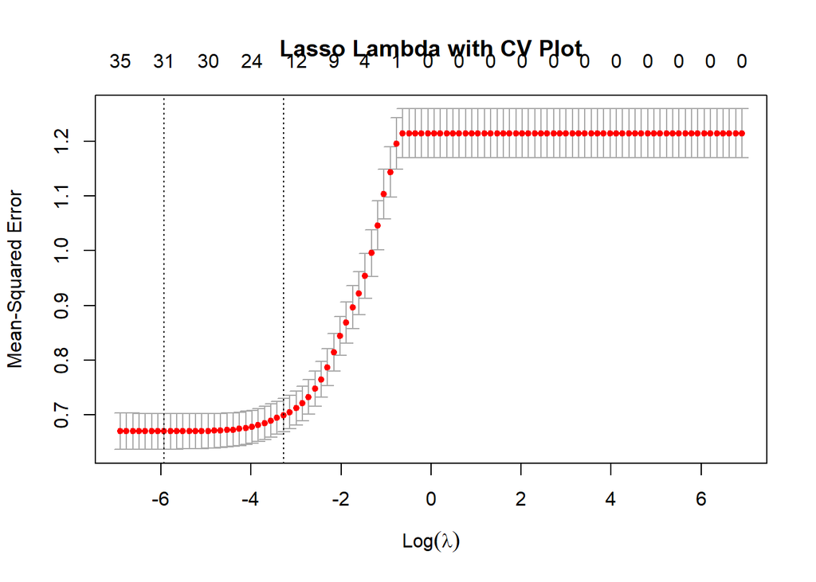

```r
# Plot cross-validation results
plot(lasso_model, main = "Lasso Lambda with CV Plot")
```

Here, 5 fold cross-validation has been applied to get the lowest MSE for the lasso.

This figure shows cross-validation results for different $log\lambda$s.

```r
# Best cross-validated lambda
lambda_lasso = lasso_model$lambda.min
lambda_lasso
```

```
## [1] 0.002656088
```

The optimal by mean squared error $\lambda$ is 0.002656088. It gives the minimum mean cross-validated error.

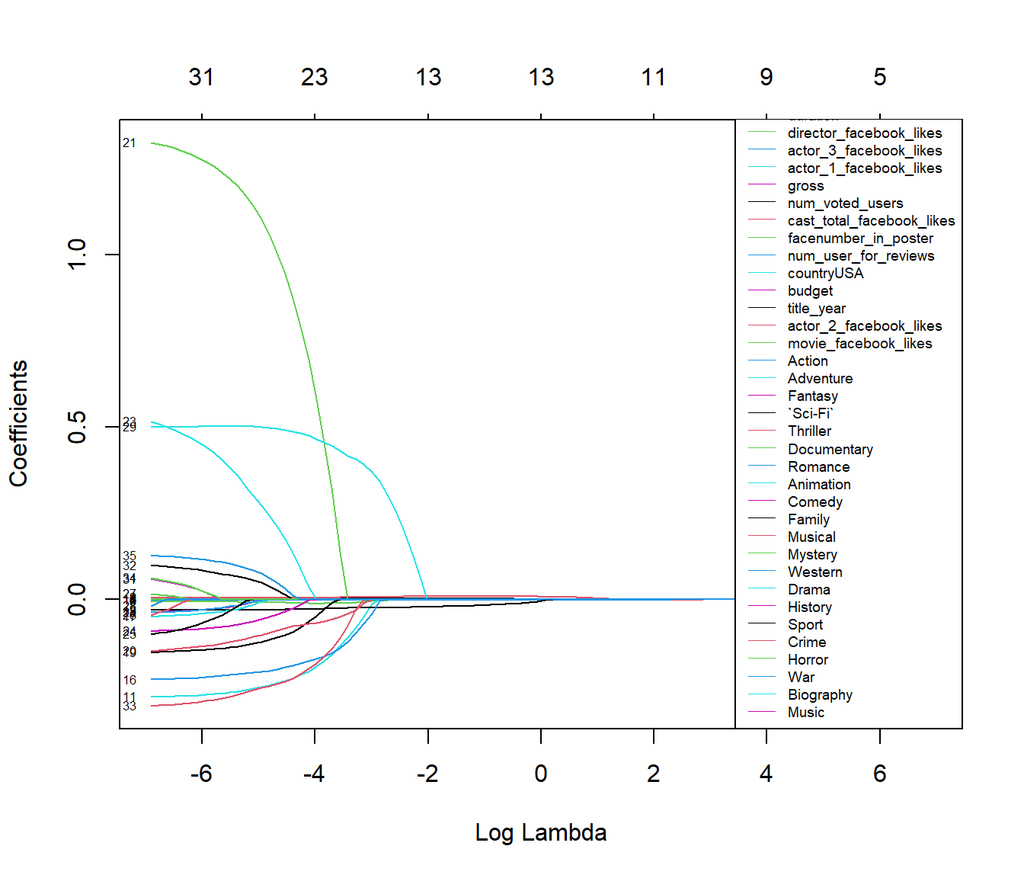

```r
# See how increasing lambda shrinks the coefficients --------------------------
# Each line shows coefficients for one variables, for different lambdas.
# The higher the lambda, the more the coefficients are shrinked towards zero.

res <- glmnet(X_train, y_train, alpha = 1, lambda = lambdas_to_try, standardize = FALSE)
plot(res, xvar = "lambda",label=TRUE)
legend("bottomright", lwd = 0.8, col = 1:6, legend = colnames(X_train), cex = .6)
```

The plot has $log(\lambda)$ on x-axis and the coefficients of the predictor variables on the y-axis. We observe that coefficients of the predictors decay to zero as $log(\lambda)$ increases.

#### Testing on testing samples

For this part, we train the lasso regression on our training sample first using the optimal $\lambda$ that we have found above.

```r
# Fit final model, get its sum of squared residuals and multiple R-squared

lasso_fit  <- glmnet(X_train, y_train, alpha = 1, lambda = lambda_lasso, standardize = TRUE)
y_hat_lasso <- predict(lasso_fit ,  X_test)

ssr_lasso =  t(y_test - y_hat_lasso) %*% (y_test - y_hat_lasso)
rsq_lasso =  cor(y_test, y_hat_lasso)^2

sse_lasso <- sum((y_hat_lasso  - y_test)^2)
R2_lasso <- 1 - sse_lasso / sst

# Evaluate performance and save it
performance <- cbind(performance, data.frame(LASSO=postResample(pred = y_hat_lasso, obs = y_test)))
performance
```

|  | Ridge | LASSO |
| --- | --- | --- |
| RMSE | 0.8020885 | 0.8028019 |
| Rsquared | 0.4627025 | 0.4623348 |
| MAE | 0.5868651 | 0.5872722 |

We found that the Lasso Regression that was trained on training sample gives an $R^2$ value of 0.4623 on the testing sample. The $R^2$ is not very good and slightly worse than the Ridge regression $R^2$ (it was 0.4627)

### C. Elastic Net

Both Ridge and LASSO’s variable selection are too dependent on the data. Elastic Net on the other hand is a combination of Ridge and Lasso.

$$\lambda_1\sum_{j=1} (\beta_j^2)+\lambda_2\sum_{j=1} (|\beta_j|)$$
or
$$\lambda((1-\alpha)/2\sum_{j=1} (\beta_j^2)+\alpha\sum_{j=1} (|\beta_j|)$$
is the Penalty term in Elastic Net. Note that,
$$\alpha_{RIDGE} = 0$$
and
$$\alpha_{LASSO} = 1$$
for Lasso.

#### Fitting Elastic Net Model and Selecting lambda using 5-fold cross-validation

First, we use the built-in function automatically select the best tuning parameters alpha and lambda. This function tests a range of possible alpha and lambda values, then selects the best values for lambda and alpha to choose the penalty term compositions, resulting to a final model that is an elastic net model.

For this part, we train the Elastic Net regression on our training sample first using the optimal $\lambda$ that we have found above.

```r
## Train the model
set.seed(412)
train_control <- trainControl(method = "cv",number = 5)

enet_model <- train(x=X_train, y=y_train,
                    method = "enet",
                    preProcess = c("center", "scale"),
                    tuneLength = 15,
                    trControl = train_control)
print(enet_model)
```

```
## Elasticnet
##
## 3436 samples
##   36 predictor
##
## Pre-processing: centered (36), scaled (36)
## Resampling: Cross-Validated (5 fold)
## Summary of sample sizes: 2748, 2749, 2749, 2750, 2748
## Resampling results across tuning parameters:
##
##   lambda        fraction   RMSE       Rsquared   MAE
##   0.0000000000  0.0500000  1.0180027  0.2615495  0.7858999
##   0.0000000000  0.1178571  0.9439830  0.3224352  0.7189513
##   0.0000000000  0.1857143  0.8986504  0.3720405  0.6811563
##   0.0000000000  0.2535714  0.8655289  0.4082358  0.6517870
##   0.0000000000  0.3214286  0.8432881  0.4271091  0.6312887
##   0.0000000000  0.3892857  0.8315252  0.4365938  0.6186409
##   0.0000000000  0.4571429  0.8240235  0.4441165  0.6106423
##   0.0000000000  0.5250000  0.8198453  0.4480288  0.6058582
##   0.0000000000  0.5928571  0.8182604  0.4495270  0.6038526
##   0.0000000000  0.6607143  0.8181177  0.4498372  0.6035357
##   0.0000000000  0.7285714  0.8179200  0.4501531  0.6033228
##   0.0000000000  0.7964286  0.8177689  0.4503532  0.6032351
##   0.0000000000  0.8642857  0.8177219  0.4504231  0.6032945
##   0.0000000000  0.9321429  0.8177609  0.4503852  0.6033919
##   0.0000000000  1.0000000  0.8178869  0.4502391  0.6035203
##   0.0001000000  0.0500000  1.0195280  0.2592402  0.7872889
##   0.0001000000  0.1178571  0.9461806  0.3204566  0.7207466
##   0.0001000000  0.1857143  0.9010347  0.3690679  0.6832503
##   0.0001000000  0.2535714  0.8678751  0.4060715  0.6538839
##   0.0001000000  0.3214286  0.8451386  0.4257664  0.6330812
##   0.0001000000  0.3892857  0.8326357  0.4355746  0.6198508
##   0.0001000000  0.4571429  0.8249603  0.4432364  0.6116766
##   0.0001000000  0.5250000  0.8203418  0.4475855  0.6064566
##   0.0001000000  0.5928571  0.8184579  0.4493852  0.6040898
##   0.0001000000  0.6607143  0.8180776  0.4497931  0.6035295
##   0.0001000000  0.7285714  0.8179819  0.4500727  0.6033711
##   0.0001000000  0.7964286  0.8178046  0.4503060  0.6032304
##   0.0001000000  0.8642857  0.8177378  0.4504030  0.6032823
##   0.0001000000  0.9321429  0.8177535  0.4503953  0.6033653
```

[output cut: 184 more lines]

```
##   0.1000000000  0.2535714  0.9240121  0.3381571  0.7027783
##   0.1000000000  0.3214286  0.9006992  0.3658756  0.6828002
##   0.1000000000  0.3892857  0.8800203  0.3904453  0.6643540
##   0.1000000000  0.4571429  0.8631673  0.4069918  0.6496717
##   0.1000000000  0.5250000  0.8498530  0.4190713  0.6375778
##   0.1000000000  0.5928571  0.8403920  0.4268369  0.6282928
##   0.1000000000  0.6607143  0.8343763  0.4316243  0.6213657
##   0.1000000000  0.7285714  0.8300742  0.4354886  0.6164925
##   0.1000000000  0.7964286  0.8273053  0.4382304  0.6131193
##   0.1000000000  0.8642857  0.8247264  0.4411985  0.6101268
##   0.1000000000  0.9321429  0.8232204  0.4431126  0.6080697
##   0.1000000000  1.0000000  0.8229128  0.4437381  0.6071812
##
## RMSE was used to select the optimal model using the smallest value.
## The final values used for the model were fraction = 0.8642857 and lambda = 0.
```

#### Testing on testing samples

```r
# Predict using the testing data
y_hat_enet <- predict(enet_model, X_test)

ssr_enet =  t(y_test - y_hat_enet) %*% (y_test - y_hat_enet)
rsq_enet =  cor(y_test, y_hat_enet)^2

sse_enet <- sum((y_hat_enet  - y_test)^2)
R2_enet <- 1 - sse_enet / sst

# Evaluate performance
performance <- cbind(performance, data.frame(ENet=postResample(pred =y_hat_enet, obs = y_test)))
performance
```

|  | Ridge | LASSO | ENet |
| --- | --- | --- | --- |
| RMSE | 0.8020885 | 0.8028019 | 0.8021508 |
| Rsquared | 0.4627025 | 0.4623348 | 0.4626408 |
| MAE | 0.5868651 | 0.5872722 | 0.5869546 |

### D. SVM

A support vector machine takes data points and outputs the hyperplane that best separates the tags. Kernel is better for making optimization when there are many features. Although Kernel SVM is more widely used as a non-linear classification model to classify binary results by projecting data into a higher dimension without increasing too much complexity of loss function, nowadays we can also apply it to regression data. And we usually refer to it as `Support Vector Regression`.

Same as SVM, SVR depends on kernel functions and also permits for construction of a non-linear model without changing the explanatory variables, helping in better interpretation of the resultant model. The basic idea behind SVR is not to care about the prediction as long as the error is less than certain value. This is known as the principle of maximal margin. This idea of maximal margin allows viewing SVR as a convex optimization problem. SVR trains using a symmetrical loss function, which equally penalizes high and low misestimates.

#### Fitting SVR and find the optimal model

```r
#find the optimal model
set.seed(412)
opt.svm <- tune(svm, train.x=X_train, train.y=y_train,cost=1:10,
                tunecontrol=tune.control(sampling = "cross"), cross=5)
print(opt.svm)
```

```
##
## Error estimation of 'svm' using 10-fold cross validation: 0.5820218
```

```r
# extract the best model
best.svm <- opt.svm$best.model
best.svm
```

```
##
## Call:
## best.tune(method = svm, train.x = X_train, train.y = y_train, tunecontrol = tune.control(sampling = "cross"),
##     cost = 1:10, cross = 5)
##
##
## Parameters:
##    SVM-Type:  eps-regression
##  SVM-Kernel:  radial
##        cost:  1 2 3 4 5 6 7 8 9 10
##       gamma:  0.02777778
##     epsilon:  0.1
##
##
## Number of Support Vectors:  2880
```

In Support Vector Regression, support vectors are points that find the closest match between the data points and the actual function that is represented by them. The CV process finds the optimal number of support vectors that find the closest match between the data points and the actual function as 2880.

#### Testing on testing samples

```r
# Predict using the testing data
y_hat_svm = predict(best.svm, X_test)

ssr_svm =  t(y_test - y_hat_svm) %*% (y_test - y_hat_svm)
rsq_svm =  cor(y_test, y_hat_svm)^2

sse_svm <- sum((y_hat_svm - y_test)^2)
R2_svm <- 1 - sse_svm / sst

# Evaluate performance
performance <- cbind(performance, data.frame(SVM=postResample(pred = y_hat_svm, obs = y_test)))
performance
```

|  | Ridge | LASSO | ENet | SVM |
| --- | --- | --- | --- | --- |
| RMSE | 0.8020885 | 0.8028019 | 0.8021508 | 0.7674338 |
| Rsquared | 0.4627025 | 0.4623348 | 0.4626408 | 0.5135524 |
| MAE | 0.5868651 | 0.5872722 | 0.5869546 | 0.5314024 |

From above result, we can see that SVM is giving better result than former models, which returns 0.5135 $R^2$.

### E. PCA (Principal Component Analysis)

PCA is used to reduce dimension when there are a lot of predictors. It creates principal components (new variables) by getting the weighted averages of the original variables through their importance. It then finds a smaller number of numerical variables that contain most of the information by eliminating redundant variables. Basically PCA is used for classification problem, but we have `Principle Component Regression (PCR)` for regression based on PCA, using some of these components as predictors in a linear regression model fitted using the typical least squares procedure.

Some of the most notable advantages of performing PCR are that it could reduce dimensionality, avoid multicollinearity between predictors and even mitigate overfitting issue.

#### Fitting PCR and choose optimal number of components

```r
set.seed(412)
pca_model <- pcr(imdb_score~.,data=IMDB_train, scale=TRUE, center=TRUE,
                 validation="CV")
summary(pca_model)
```

```
## Data:    X dimension: 3436 36
##  Y dimension: 3436 1
## Fit method: svdpc
## Number of components considered: 36
##
## VALIDATION: RMSEP
## Cross-validated using 10 random segments.
##        (Intercept)  1 comps  2 comps  3 comps  4 comps  5 comps  6 comps
## CV           1.102    1.041    1.002   0.9903   0.9476   0.9456   0.9456
## adjCV        1.102    1.040    1.002   0.9897   0.9472   0.9454   0.9454
##        7 comps  8 comps  9 comps  10 comps  11 comps  12 comps  13 comps
## CV      0.9399   0.9315   0.9260    0.9254    0.9252    0.9257    0.9150
## adjCV   0.9395   0.9306   0.9259    0.9255    0.9254    0.9263    0.9169
##        14 comps  15 comps  16 comps  17 comps  18 comps  19 comps  20 comps
## CV       0.9015    0.9005    0.9014    0.9000    0.9015    0.8978    0.8971
## adjCV    0.8990    0.8996    0.9010    0.8995    0.9012    0.8971    0.8966
##        21 comps  22 comps  23 comps  24 comps  25 comps  26 comps  27 comps
## CV       0.8943    0.8753    0.8735    0.8707    0.8708    0.8703    0.8607
## adjCV    0.8941    0.8747    0.8728    0.8701    0.8703    0.8698    0.8601
##        28 comps  29 comps  30 comps  31 comps  32 comps  33 comps  34 comps
## CV       0.8583    0.8580    0.8575    0.8546    0.8546    0.8544    0.8448
## adjCV    0.8576    0.8573    0.8568    0.8535    0.8539    0.8538    0.8441
##        35 comps  36 comps
## CV       0.8181    0.8174
## adjCV    0.8175    0.8168
##
## TRAINING: % variance explained
##             1 comps  2 comps  3 comps  4 comps  5 comps  6 comps  7 comps
## X             13.04    20.71    27.34    33.05    37.60    41.60    45.26
## imdb_score    11.22    17.69    20.16    26.43    26.72    26.73    27.73
##             8 comps  9 comps  10 comps  11 comps  12 comps  13 comps  14 comps
## X             48.79    52.20     55.22     58.13     60.93     63.63     66.30
## imdb_score    29.10    29.73     29.86     30.01     30.10     31.80     33.77
##             15 comps  16 comps  17 comps  18 comps  19 comps  20 comps
## X              68.92     71.35     73.74     76.12     78.44     80.64
## imdb_score     33.99     34.04     34.17     34.17     35.22     35.63
##             21 comps  22 comps  23 comps  24 comps  25 comps  26 comps
## X              82.71     84.68     86.41     88.03      89.6     91.08
## imdb_score     35.83     38.20     38.55     38.90      38.9     39.15
##             27 comps  28 comps  29 comps  30 comps  31 comps  32 comps
## X              92.45     93.70     94.86     95.99     97.00     97.98
## imdb_score     40.54     40.91     40.92     41.08     41.52     41.53
##             33 comps  34 comps  35 comps  36 comps
## X              98.92     99.59    100.00    100.00
## imdb_score     41.54     42.78     46.22     46.38
```

In this model, we are able to explain up to 46.38% of the variance if we use all 36 components.

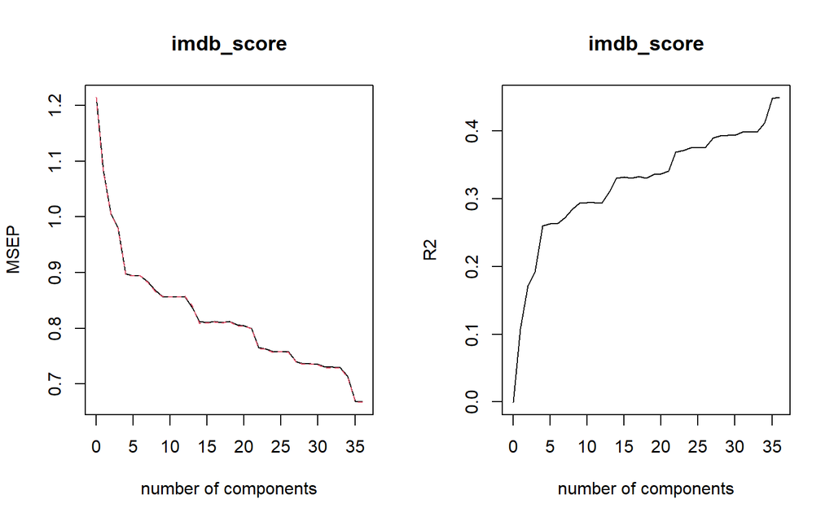

```r
par(mfrow=c(1,2))
validationplot(pca_model,val.type = "MSEP")
validationplot(pca_model,val.type = "R2")
```

How many components to pick is subjective, however, there is almost no improvement beyond PC35 but before that we can always observe some improvements when we include more components. And let’s take a look at the score plot.

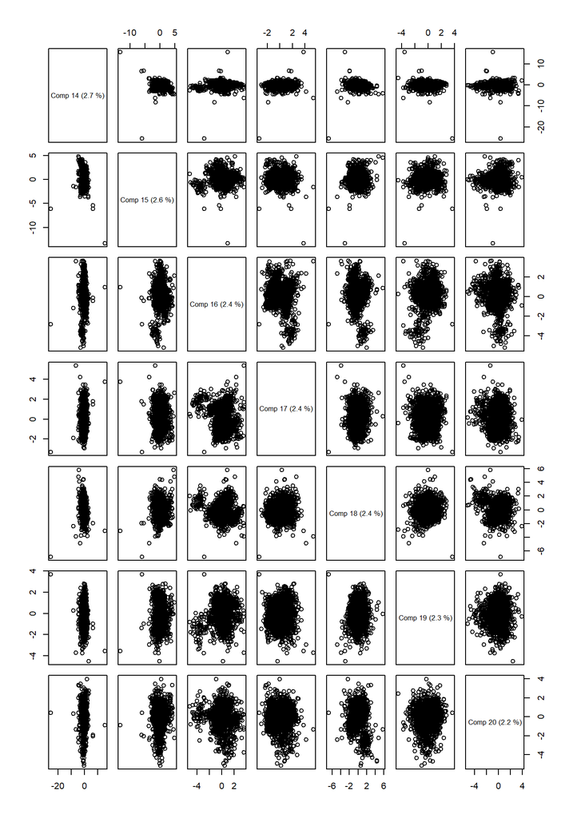

```r
scoreplot(pca_model, comps = 14:20)
```

From the above plot we can see that after including Component 17 & 18, the variance is not explained more and the model does not improve much, as we expected. So it is more ideal to choose 16 components to achieve parsimony and reduce dimensionality.

#### Testing on testing samples

```r
set.seed(412)
pca_model <- pcr(imdb_score~.,data=IMDB_train, ncomp=16, scale=TRUE, center=TRUE,
                 validation="CV")

# Predict using the testing data
y_hat_pca = predict(pca_model, newdata=X_test)
y_hat_pca = y_hat_pca[1:length(y_test),1,16]

ssr_pca =  t(y_test - y_hat_pca) %*% (y_test - y_hat_pca)
rsq_pca =  cor(y_test, y_hat_pca)^2

sse_pca <- sum((y_hat_pca - y_test)^2)
R2_pca <- 1 - sse_pca / sst

# Evaluate performance
performance <- cbind(performance, data.frame(PCA=postResample(pred = y_hat_pca, obs = y_test)))
performance
```

|  | Ridge | LASSO | ENet | SVM | PCA |
| --- | --- | --- | --- | --- | --- |
| RMSE | 0.8020885 | 0.8028019 | 0.8021508 | 0.7674338 | 0.8844928 |
| Rsquared | 0.4627025 | 0.4623348 | 0.4626408 | 0.5135524 | 0.3475206 |
| MAE | 0.5868651 | 0.5872722 | 0.5869546 | 0.5314024 | 0.6693726 |

The PCA model is not performing that well, and we can see that in the process of choosing components. Because all of the components are explaining similar variation of the data, dimensionality reduction does not improve the model much and even gives the worst results. The PCA model drops the dummy variables of genres and since genres are important factors in detecting the imdb score, it doesn’t really make sense achieve parsimony in this dataset.

### F. Random Forest

Random forest can be used as an ensemble learning method for classification by establishing a multitude of decision trees at training time and outputting the class. It is efficient on large data bases. Random Forest consists of a large number of individual decision trees that operate as an ensemble and operates among multiple decision trees to find the optimal values by choosing the majority among them as the best value. Each decision tree under the random forest gives a values and random forest chooses the value that has the highest votes.

Some of the most notable advantages of performing Random Forests are that it could mitigate overfitting issue and it usually shows better performance and have higher accuracy.

#### Fitting Random Forest and find the optimal model

```r
train_control <- trainControl(method = "cv",number = 5, search="grid")

set.seed(412)
rf_model <- train(x=X_train, y=y_train,method = "rf",
                  preProcess = c("center", "scale"),
                  trControl = train_control)

print(rf_model)
```

```
## Random Forest
##
## 3436 samples
##   36 predictor
##
## Pre-processing: centered (36), scaled (36)
## Resampling: Cross-Validated (5 fold)
## Summary of sample sizes: 2748, 2749, 2749, 2750, 2748
## Resampling results across tuning parameters:
##
##   mtry  RMSE       Rsquared   MAE
##    2    0.8008476  0.5268543  0.5914542
##   19    0.7314068  0.5663248  0.5216415
##   36    0.7327379  0.5603647  0.5223217
##
## RMSE was used to select the optimal model using the smallest value.
## The final value used for the model was mtry = 19.
```

The number of variables selected at each split is denoted by mtry in randomforest function. mtry = 19 gives the smallest RMSE value and highest $\R^2$ value. Thus, it is the optimal number of variables at each split.

#### Testing on testing samples

```r
# Predict using the testing data
y_hat_rf = predict(rf_model, newdata=X_test)

ssr_rf =  t(y_test - y_hat_rf) %*% (y_test - y_hat_rf)
rsq_rf =  cor(y_test, y_hat_rf)^2

sse_rf <- sum((y_hat_rf - y_test)^2)
R2_rf <- 1 - sse_rf / sst

# Evaluate performance
performance <- cbind(performance, data.frame(RandomForest=postResample(pred = y_hat_rf, obs = y_test)))
performance
```

|  | Ridge | LASSO | ENet | SVM | PCA | RandomForest |
| --- | --- | --- | --- | --- | --- | --- |
| RMSE | 0.8020885 | 0.8028019 | 0.8021508 | 0.7674338 | 0.8844928 | 0.7290288 |
| Rsquared | 0.4627025 | 0.4623348 | 0.4626408 | 0.5135524 | 0.3475206 | 0.5603316 |
| MAE | 0.5868651 | 0.5872722 | 0.5869546 | 0.5314024 | 0.6693726 | 0.5210546 |

As seen from the results above, Random Forest gives the highest $R^2$ and lowest RMSE and MAE. It even beats our previous best model, SVM, which had 0.5135524 $R^2$. Random forest gives an $R^2$ of 0.5603316 which is still not very high but still the best among all of the models that we have tried.

If we choose best model according to $R^2$, Random Forest will be the best model on testing samples.

## IV. Evaluating Model Performance - using CV

```r
X = model.matrix(imdb_score ~ ., IMDB)[, -1]
Y = IMDB$imdb_score
```

### A. Ridge with CV

```r
# Perform 10-fold cross-validation on entire dataset
set.seed(412)
lambdas_to_try <- 10^seq(-3, 3, length.out = 100)

ridge_cv = cv.glmnet(X, Y, alpha = 0, lambda = lambdas_to_try,
                      standardize = TRUE, nfolds = 5)

# Fit the optimal model
ridge_cv <- glmnet(X, Y, alpha = 0, lambda = ridge_cv$lambda.min, standardize = TRUE)

#Predict
y_ridge_cv <- predict(ridge_cv, X)

# Evaluate performance and save it
cv_perf <- data.frame(Ridge_CV=postResample(pred = y_ridge_cv, obs = Y))
cv_perf
```

|  | Ridge_CV |
| --- | --- |
| RMSE | 0.8049287 |
| Rsquared | 0.4640727 |
| MAE | 0.5915019 |

### B. LASSO with CV

```r
# Perform 10-fold cross-validation on entire dataset
set.seed(412)
lambdas_to_try <- 10^seq(-3, 3, length.out = 100)

lasso_cv = cv.glmnet(X, Y, alpha = 1, lambda = lambdas_to_try,
                      standardize = TRUE, nfolds = 5)

# Fit the optimal model
lasso_cv <- glmnet(X, Y, alpha = 1, lambda = lasso_cv$lambda.min, standardize = TRUE)

#Predict
y_lasso_cv <- predict(lasso_cv, X)

# Evaluate performance and save it
cv_perf <- cbind(cv_perf, data.frame(LASSO_CV=postResample(pred = y_lasso_cv, obs = Y)))
cv_perf
```

|  | Ridge_CV | LASSO_CV |
| --- | --- | --- |
| RMSE | 0.8049287 | 0.8057929 |
| Rsquared | 0.4640727 | 0.4629841 |
| MAE | 0.5915019 | 0.5922008 |

### C. ElasticNet with CV

```r
# Perform 10-fold cross-validation on entire dataset
train_control <- trainControl(method = "cv",number = 5)

set.seed(412)
enet_cv <- train(x=X, y=Y, method = "enet",
                 preProcess = c("center", "scale"),
                 tuneLength = 15, trControl = train_control)


#Predict
y_enet_cv <- predict(enet_cv, X)

# Evaluate performance
cv_perf <- cbind(cv_perf, data.frame(ENET_CV=postResample(pred = y_enet_cv, obs = Y)))
cv_perf
```

|  | Ridge_CV | LASSO_CV | ENET_CV |
| --- | --- | --- | --- |
| RMSE | 0.8049287 | 0.8057929 | 0.8047597 |
| Rsquared | 0.4640727 | 0.4629841 | 0.4642969 |
| MAE | 0.5915019 | 0.5922008 | 0.5914304 |

### D. SVM with CV

```r
set.seed(412)

opt.svm_cv <- tune(svm, train.x=X, train.y=Y, cost=1:10,
               tunecontrol=tune.control(sampling = "cross"), cross=5)

# Find the optimal model
best.svm_cv <- opt.svm_cv$best.model

#Predict
y_svm_cv = predict(best.svm_cv, X)

# Evaluate performance
cv_perf <- cbind(cv_perf, data.frame(SVM_CV=postResample(pred = y_svm_cv , obs = Y)))
cv_perf
```

|  | Ridge_CV | LASSO_CV | ENET_CV | SVM_CV |
| --- | --- | --- | --- | --- |
| RMSE | 0.8049287 | 0.8057929 | 0.8047597 | 0.6641020 |
| Rsquared | 0.4640727 | 0.4629841 | 0.4642969 | 0.6464760 |
| MAE | 0.5915019 | 0.5922008 | 0.5914304 | 0.4205567 |

### E. PCA with CV

```r
set.seed(412)

pca_model_cv <- pcr(imdb_score~.,data=IMDB, scale=TRUE, center=TRUE,
                 validation="CV")

summary(pca_model_cv)
```

```
## Data:    X dimension: 4581 36
##  Y dimension: 4581 1
## Fit method: svdpc
## Number of components considered: 36
##
## VALIDATION: RMSEP
## Cross-validated using 10 random segments.
##        (Intercept)  1 comps  2 comps  3 comps  4 comps  5 comps  6 comps
## CV             1.1    1.042    1.008        1   0.9450   0.9439   0.9439
## adjCV          1.1    1.042    1.007        1   0.9447   0.9437   0.9437
##        7 comps  8 comps  9 comps  10 comps  11 comps  12 comps  13 comps
## CV      0.9382   0.9310   0.9238    0.9244    0.9241    0.9242    0.9192
## adjCV   0.9380   0.9307   0.9236    0.9243    0.9242    0.9243    0.9189
##        14 comps  15 comps  16 comps  17 comps  18 comps  19 comps  20 comps
## CV       0.9003    0.8997    0.8977    0.8978    0.9002    0.8914    0.8858
## adjCV    0.8992    0.8990    0.8977    0.8976    0.9008    0.8913    0.8853
##        21 comps  22 comps  23 comps  24 comps  25 comps  26 comps  27 comps
## CV       0.8858    0.8706    0.8677    0.8654    0.8644    0.8637    0.8570
## adjCV    0.8855    0.8703    0.8674    0.8649    0.8641    0.8634    0.8568
##        28 comps  29 comps  30 comps  31 comps  32 comps  33 comps  34 comps
## CV       0.8534    0.8511    0.8502    0.8499    0.8490    0.8475    0.8401
## adjCV    0.8529    0.8497    0.8496    0.8496    0.8485    0.8472    0.8397
##        35 comps  36 comps
## CV       0.8128    0.8121
## adjCV    0.8124    0.8117
##
## TRAINING: % variance explained
##             1 comps  2 comps  3 comps  4 comps  5 comps  6 comps  7 comps
## X             12.86    20.56    27.16    32.97    37.49    41.54    45.22
## imdb_score    10.49    16.49    17.94    26.48    26.63    26.63    27.53
##             8 comps  9 comps  10 comps  11 comps  12 comps  13 comps  14 comps
## X             48.78    52.17     55.19     58.08     60.89     63.58     66.19
## imdb_score    28.75    29.82     29.83     29.84     29.87     31.05     33.93
##             15 comps  16 comps  17 comps  18 comps  19 comps  20 comps
## X              68.69     71.12     73.52     75.89     78.21     80.38
## imdb_score     33.93     33.93     34.07     34.08     35.35     36.16
##             21 comps  22 comps  23 comps  24 comps  25 comps  26 comps
## X              82.48     84.49     86.19     87.82     89.38     90.83
## imdb_score     36.19     38.15     38.57     39.02     39.09     39.28
##             27 comps  28 comps  29 comps  30 comps  31 comps  32 comps
## X              92.23     93.46     94.65     95.80     96.95     97.93
## imdb_score     40.12     40.62     41.14     41.25     41.36     41.53
##             33 comps  34 comps  35 comps  36 comps
## X              98.89     99.56    100.00    100.00
## imdb_score     41.64     42.69     46.31     46.43
```

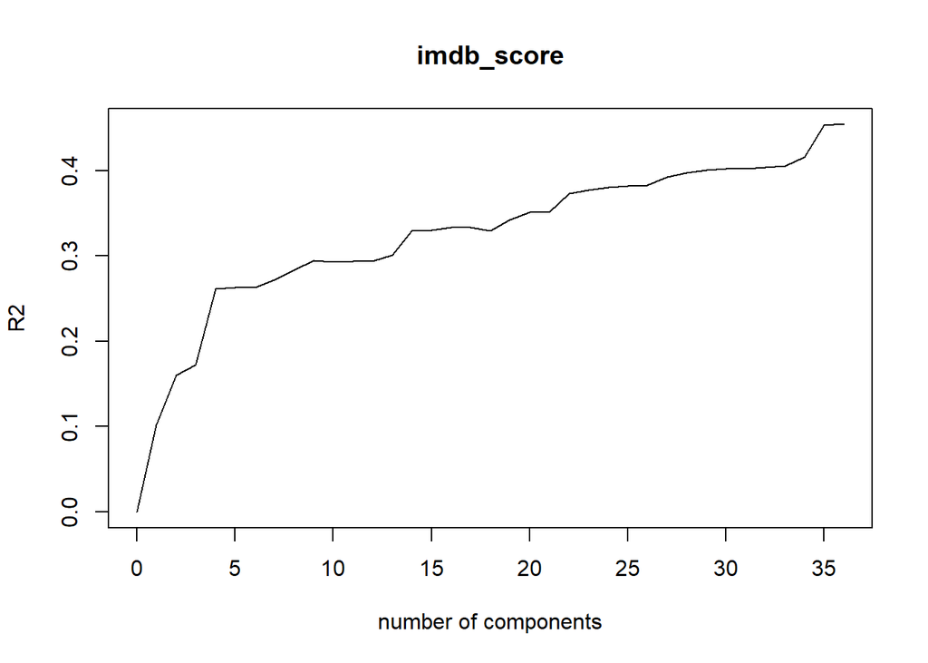

```r
validationplot(pca_model_cv,val.type = "R2")
```

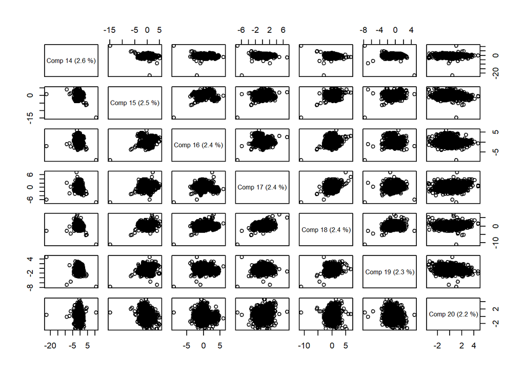

```r
scoreplot(pca_model_cv, comps = 14:20)
```

```r
set.seed(412)

# Fit the optimal model, still with 16 components
pca_cv <- pcr(imdb_score~.,data=IMDB, ncomp=16, scale=TRUE, center=TRUE,
                 validation="CV")
#Predict
y_pca_cv <- predict(pca_cv, X)

# Evaluate performance and save it
cv_perf <- cbind(cv_perf, data.frame(PCA_CV=postResample(pred = y_pca_cv, obs = Y)))
cv_perf
```

|  | Ridge_CV | LASSO_CV | ENET_CV | SVM_CV | PCA_CV |
| --- | --- | --- | --- | --- | --- |
| RMSE | 0.8049287 | 0.8057929 | 0.8047597 | 0.6641020 | NA |
| Rsquared | 0.4640727 | 0.4629841 | 0.4642969 | 0.6464760 | 0.1049028 |
| MAE | 0.5915019 | 0.5922008 | 0.5914304 | 0.4205567 | NA |

### F. Random Forest with CV

```r
# Perform 10-fold cross-validation on entire dataset

train_control <- trainControl(method = "cv",number = 5, search="grid")

set.seed(412)
rf_cv <- train(x=X, y=Y, method = "rf",preProcess = c("center", "scale"),
                  trControl = train_control)

#Predict
y_rf_cv <- predict(rf_cv, X)

# Evaluate performance and save it
cv_perf <- cbind(cv_perf, data.frame(RandomForest_CV=postResample(pred = y_rf_cv, obs = Y)))
cv_perf
```

|  | Ridge_CV | LASSO_CV | ENET_CV | SVM_CV | PCA_CV | RandomForest_CV |
| --- | --- | --- | --- | --- | --- | --- |
| RMSE | 0.8049287 | 0.8057929 | 0.8047597 | 0.6641020 | NA | 0.2948366 |
| Rsquared | 0.4640727 | 0.4629841 | 0.4642969 | 0.6464760 | 0.1049028 | 0.9495742 |
| MAE | 0.5915019 | 0.5922008 | 0.5914304 | 0.4205567 | NA | 0.2048249 |

### Results:

Our 5-fold cross-validation gives similar results to our previous findings in terms of the best model.

## V.Conclusion and Future Work

For our dataset, we have understood that PCA model was not performing well since we didn’t have many predictors already and dropping genres dummies with PCA model resulted in dropping an important variable. Since genres are improtant factors that makes a movie successful, dimensionality reduction did not help us much. Our analysis can still be improved with more sophisticated methods such as neural networks or KNN. These methods can be added to improve our outcomes in the future and to help the film industry as well.

# VI. Reference

- https://data.world/data-society/imdb-5000-movie-dataset